# Trabajo 1 — Tres series: descripción, operador de rezago, dependencia, pronóstico y argumentación

#### 6.2.0.2 Tendencia con ficticias de suma cero (sostenido)

Ajuste por mínimos cuadrados sobre las 120 observaciones, 5 coeficientes; HAC con núcleo de Bartlett y $L=4$ rezagos.

| Coeficiente | Estimación | e.e. ordinario | e.e. HAC | HAC / ordinario | t robusta | Valor p |
| --- | --- | --- | --- | --- | --- | --- |
| beta0 (intercepto) | 1956,8251 | 9,4196 | 12,4630 | 1,3231 | 157,0108 | <1e-04 |
| beta1 (t) | 15,4938 | 0,1351 | 0,1790 | 1,3244 | 86,5721 | <1e-04 |
| gamma1 (estacion 1) | -120,4269 | 8,1061 | 5,9707 | 0,7366 | -20,1696 | <1e-04 |
| gamma2 (estacion 2) | 43,4194 | 8,1038 | 6,0248 | 0,7435 | 7,2068 | <1e-04 |
| gamma3 (estacion 3) | 154,0390 | 8,1038 | 5,9960 | 0,7399 | 25,6904 | <1e-04 |
| gamma4 (estacion 4) | -77,0315 | 8,1061 | 6,3039 | 0,7777 | -12,2196 | <1e-04 |

**Pruebas t con el error estándar robusto.**

| 1. Hipótesis | 2. Estadístico y distribución | 3. Región de rechazo | 4. Observado y valor p | 5. Decisión | 6. Lectura |
| --- | --- | --- | --- | --- | --- |
| H0: beta0 (intercepto) = 0; H1: beta0 (intercepto) != 0 | t = b / ee_HAC(b) ~ t de Student con 115 g.l. (aproximada) | \|t\| > 1.981 | t = 157.011; p = <1e-04 | Se rechaza H0 al 5 % | El nivel en t = 0 es distinto de cero. |
| H0: beta1 (t) = 0; H1: beta1 (t) != 0 | t = b / ee_HAC(b) ~ t de Student con 115 g.l. (aproximada) | \|t\| > 1.981 | t = 86.572; p = <1e-04 | Se rechaza H0 al 5 % | Hay tendencia significativa: un cambio de 15,494 miles de pasajeros por periodo. |
| H0: gamma1 (estacion 1) = 0; H1: gamma1 (estacion 1) != 0 | t = b / ee_HAC(b) ~ t de Student con 115 g.l. (aproximada) | \|t\| > 1.981 | t = -20.170; p = <1e-04 | Se rechaza H0 al 5 % | La estacion 1 se aparta del nivel de su ano en -120,4 miles de pasajeros. |
| H0: gamma2 (estacion 2) = 0; H1: gamma2 (estacion 2) != 0 | t = b / ee_HAC(b) ~ t de Student con 115 g.l. (aproximada) | \|t\| > 1.981 | t = 7.207; p = <1e-04 | Se rechaza H0 al 5 % | La estacion 2 se aparta del nivel de su ano en 43,4 miles de pasajeros. |
| H0: gamma3 (estacion 3) = 0; H1: gamma3 (estacion 3) != 0 | t = b / ee_HAC(b) ~ t de Student con 115 g.l. (aproximada) | \|t\| > 1.981 | t = 25.690; p = <1e-04 | Se rechaza H0 al 5 % | La estacion 3 se aparta del nivel de su ano en 154,0 miles de pasajeros. |
| H0: gamma4 (estacion 4) = 0; H1: gamma4 (estacion 4) != 0 | t = b / ee_HAC(b) ~ t de Student con 115 g.l. (aproximada) | \|t\| > 1.981 | t = -12.220; p = <1e-04 | Se rechaza H0 al 5 % | La estacion 4 se aparta del nivel de su ano en -77,0 miles de pasajeros. |

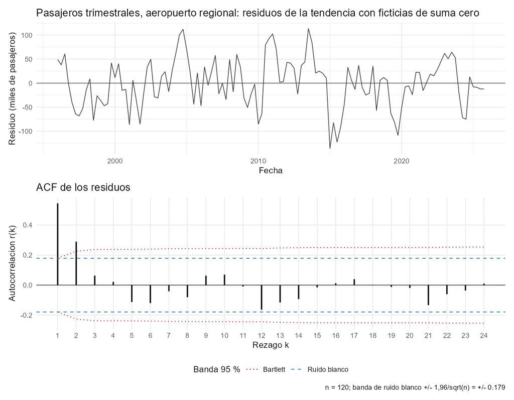

Residuos en el tiempo y su correlograma, tendencia con ficticias de suma cero.

Rezagos de la ACF de los residuos fuera de la banda $\pm 1{,}96/\sqrt{n}$: 1-2.

**Ljung–Box sobre los residuos.**

| Elemento | Contenido |
| --- | --- |
| 1. Hipotesis | H0: rho(1) = … = rho(8) = 0; H1: rho(k) != 0 para algun k en 1, …, 8 |
| 2. Estadistico y distribucion | Q = n(n+2) sum_{k=1}^{m} r_k^2/(n-k) ~ chi-cuadrado con 8 g.l. bajo H0 |
| 3. Region de rechazo (5 %) | Q > 15.507 |
| 4. Observado y valor p | observado = 52.0305; valor p = 1.66e-08 |
| 5. Decision | Se rechaza H0 al 5 % |
| 6. Lectura | Hay autocorrelacion conjunta significativa en los primeros 8 rezagos de los residuos de la tendencia con ficticias de suma cero. |

**Jarque–Bera sobre los residuos.**

| Elemento | Contenido |
| --- | --- |
| 1. Hipotesis | H0: asimetria = 0 y curtosis = 3 (normalidad); H1: asimetria != 0 o curtosis != 3 |
| 2. Estadistico y distribucion | JB = n/6 [A^2 + (K - 3)^2/4] ~ chi-cuadrado con 2 g.l. (asintotica) bajo H0 |
| 3. Region de rechazo (5 %) | JB > 5.991 |
| 4. Observado y valor p | observado = 0.6692; valor p = 0.7156 |
| 5. Decision | No se rechaza H0 al 5 % |
| 6. Lectura | No se rechaza normalidad de los errores. |

**Durbin–Watson (diagnóstico).** $d=0,901$, con $r_1=0,545$ y $2(1-r_1)=0,910$.

**Lectura de la tendencia con ficticias.** La pendiente es de 15,49 miles de pasajeros por trimestre, la misma que se encontró en 4(c), y los cuatro efectos estacionales son significativos con el error robusto: el trimestre 3 está 154,0 miles por encima del nivel de su año y el 1, 120,4 por debajo. Los residuos conservan autocorrelación positiva de corto plazo: $r_1=0,55$, $d=0,90$ y Ljung–Box rechaza ($Q=52,0$ con $m=8$). El nivel se aparta de la recta durante varios trimestres seguidos, de modo que la tendencia global es demasiado rígida; eso es lo que Holt–Winters puede capturar al dejar que el nivel se mueva. Por la misma razón el error HAC de la pendiente es 1,32 veces el ordinario. Los residuos son compatibles con la normalidad ($JB=0,67$).

**Código**

```r
bloque_6b("serie2", "tend_lineal")
```

#### 6.2.0.3 Tendencia lineal (contraste)

Ajuste por mínimos cuadrados sobre las 120 observaciones, 2 coeficientes; HAC con núcleo de Bartlett y $L=4$ rezagos.

| Coeficiente | Estimación | e.e. ordinario | e.e. HAC | HAC / ordinario | t robusta | Valor p |
| --- | --- | --- | --- | --- | --- | --- |
| beta0 (intercepto) | 1955,3074 | 21,9443 | 15,0263 | 0,6847 | 130,1260 | <1e-04 |
| beta1 (t) | 15,5188 | 0,3148 | 0,2140 | 0,6799 | 72,5118 | <1e-04 |

**Pruebas t con el error estándar robusto.**

| 1. Hipótesis | 2. Estadístico y distribución | 3. Región de rechazo | 4. Observado y valor p | 5. Decisión | 6. Lectura |
| --- | --- | --- | --- | --- | --- |
| H0: beta0 (intercepto) = 0; H1: beta0 (intercepto) != 0 | t = b / ee_HAC(b) ~ t de Student con 118 g.l. (aproximada) | \|t\| > 1.980 | t = 130.126; p = <1e-04 | Se rechaza H0 al 5 % | El nivel en t = 0 es distinto de cero. |
| H0: beta1 (t) = 0; H1: beta1 (t) != 0 | t = b / ee_HAC(b) ~ t de Student con 118 g.l. (aproximada) | \|t\| > 1.980 | t = 72.512; p = <1e-04 | Se rechaza H0 al 5 % | Hay tendencia significativa: un cambio de 15,519 miles de pasajeros por periodo. |

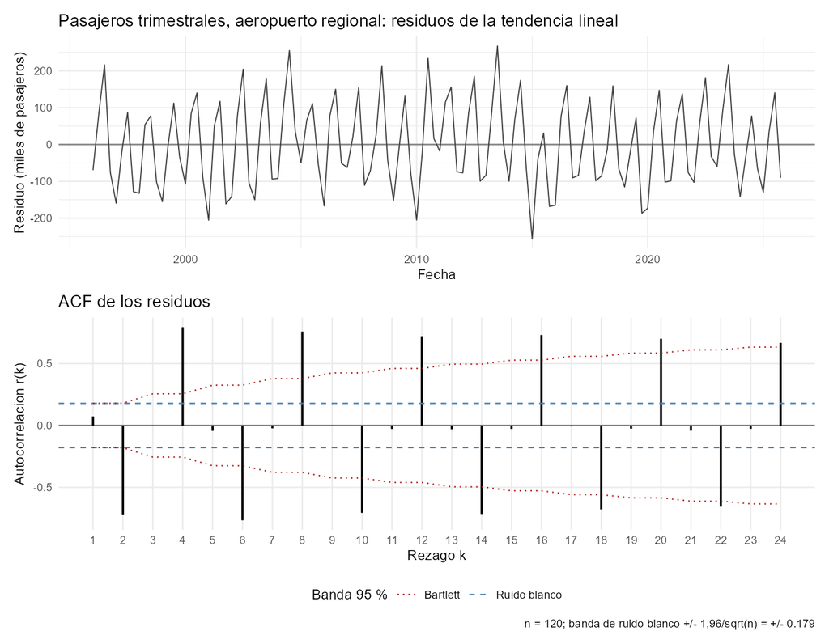

Residuos en el tiempo y su correlograma, tendencia lineal.

Rezagos de la ACF de los residuos fuera de la banda $\pm 1{,}96/\sqrt{n}$: 2, 4, 6, 8, 10, 12, 14, 16, 18, 20, 22, 24.

**Ljung–Box sobre los residuos.**

| Elemento | Contenido |
| --- | --- |
| 1. Hipotesis | H0: rho(1) = … = rho(8) = 0; H1: rho(k) != 0 para algun k en 1, …, 8 |
| 2. Estadistico y distribucion | Q = n(n+2) sum_{k=1}^{m} r_k^2/(n-k) ~ chi-cuadrado con 8 g.l. bajo H0 |
| 3. Region de rechazo (5 %) | Q > 15.507 |
| 4. Observado y valor p | observado = 295.3807; valor p = < 2.2e-16 |
| 5. Decision | Se rechaza H0 al 5 % |
| 6. Lectura | Hay autocorrelacion conjunta significativa en los primeros 8 rezagos de los residuos de la tendencia lineal. |

**Jarque–Bera sobre los residuos.**

| Elemento | Contenido |
| --- | --- |
| 1. Hipotesis | H0: asimetria = 0 y curtosis = 3 (normalidad); H1: asimetria != 0 o curtosis != 3 |
| 2. Estadistico y distribucion | JB = n/6 [A^2 + (K - 3)^2/4] ~ chi-cuadrado con 2 g.l. (asintotica) bajo H0 |
| 3. Region de rechazo (5 %) | JB > 5.991 |
| 4. Observado y valor p | observado = 4.8084; valor p = 0.09034 |
| 5. Decision | No se rechaza H0 al 5 % |
| 6. Lectura | No se rechaza normalidad de los errores. |

**Durbin–Watson (diagnóstico).** $d=1,845$, con $r_1=0,073$ y $2(1-r_1)=1,853$.

**Lectura de la recta sin ficticias (contraste).** La pendiente estimada casi no cambia (15,52), pero los residuos guardan todo el patrón estacional: la ACF queda fuera de la banda en los rezagos pares (2, 4, 6, …), alternando signo, y Ljung–Box da $Q=295,4$. El caso muestra por qué Durbin–Watson es solo un diagnóstico: $d=1,85$ parece cercano a 2 porque solo mira el rezago 1, mientras la estructura está en los rezagos 2 y 4. Aquí el error HAC es menor que el ordinario: la autocorrelación de los residuos alterna de signo y sus términos negativos reducen la varianza de largo plazo.

**Serie 3: viajes de la plataforma**

**Código**

```r
bloque_6b("serie3", "tend_exponencial")
```

#### 6.2.0.4 Tendencia exponencial (sostenido)

Ajuste por mínimos cuadrados sobre las 144 observaciones, 2 coeficientes; HAC con núcleo de Bartlett y $L=4$ rezagos. Los coeficientes y los residuos están en la escala de $\ln Y_t$.

| Coeficiente | Estimación | e.e. ordinario | e.e. HAC | HAC / ordinario | t robusta | Valor p |
| --- | --- | --- | --- | --- | --- | --- |
| beta0 (intercepto) | 4,3784 | 0,0064 | 0,0055 | 0,8486 | 802,0843 | <1e-04 |
| beta1 (t) | 0,0121 | 0,0001 | 0,0001 | 1,1275 | 138,9714 | <1e-04 |

**Pruebas t con el error estándar robusto.**

| 1. Hipótesis | 2. Estadístico y distribución | 3. Región de rechazo | 4. Observado y valor p | 5. Decisión | 6. Lectura |
| --- | --- | --- | --- | --- | --- |
| H0: beta0 (intercepto) = 0; H1: beta0 (intercepto) != 0 | t = b / ee_HAC(b) ~ t de Student con 142 g.l. (aproximada) | \|t\| > 1.977 | t = 802.084; p = <1e-04 | Se rechaza H0 al 5 % | El nivel en t = 0 es distinto de cero. |
| H0: beta1 (t) = 0; H1: beta1 (t) != 0 | t = b / ee_HAC(b) ~ t de Student con 142 g.l. (aproximada) | \|t\| > 1.977 | t = 138.971; p = <1e-04 | Se rechaza H0 al 5 % | Hay tendencia significativa: una tasa de crecimiento de 1,21 % por periodo. |

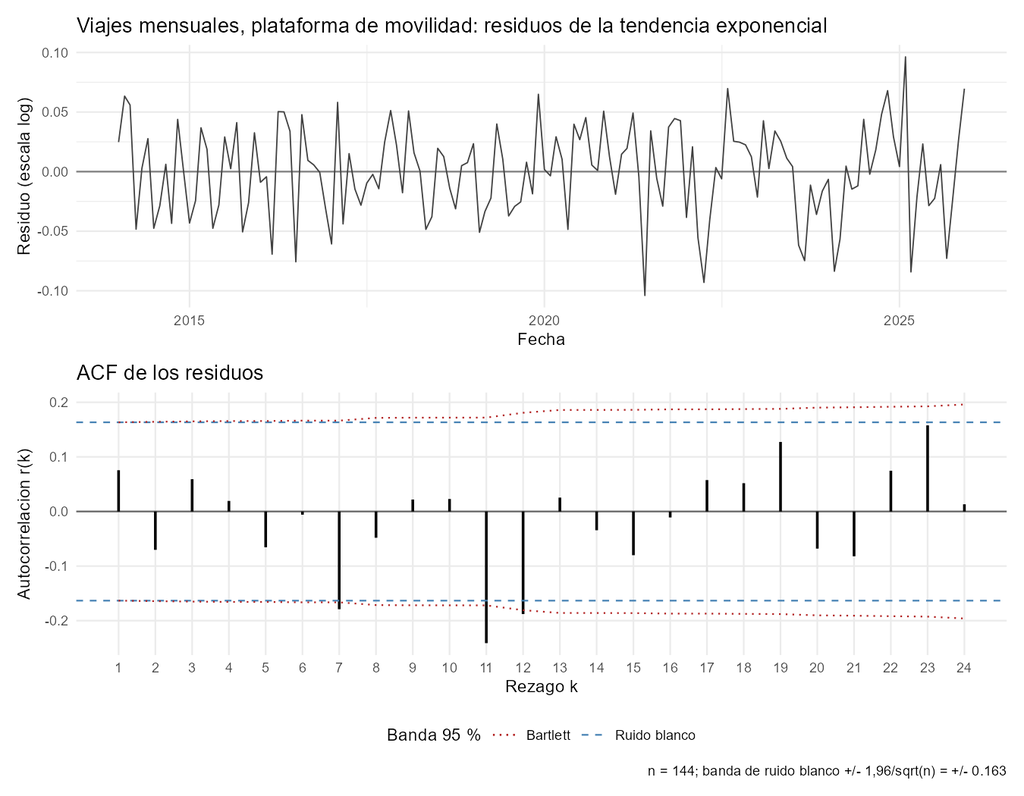

Residuos en el tiempo y su correlograma, tendencia exponencial.

Rezagos de la ACF de los residuos fuera de la banda $\pm 1{,}96/\sqrt{n}$: 7, 11-12.

**Ljung–Box sobre los residuos.**

| Elemento | Contenido |
| --- | --- |
| 1. Hipotesis | H0: rho(1) = … = rho(24) = 0; H1: rho(k) != 0 para algun k en 1, …, 24 |
| 2. Estadistico y distribucion | Q = n(n+2) sum_{k=1}^{m} r_k^2/(n-k) ~ chi-cuadrado con 24 g.l. bajo H0 |
| 3. Region de rechazo (5 %) | Q > 36.415 |
| 4. Observado y valor p | observado = 35.3718; valor p = 0.06308 |
| 5. Decision | No se rechaza H0 al 5 % |
| 6. Lectura | No hay evidencia de autocorrelacion conjunta en los primeros 24 rezagos de los residuos de la tendencia exponencial; es compatible con ruido blanco. |

**Jarque–Bera sobre los residuos.**

| Elemento | Contenido |
| --- | --- |
| 1. Hipotesis | H0: asimetria = 0 y curtosis = 3 (normalidad); H1: asimetria != 0 o curtosis != 3 |
| 2. Estadistico y distribucion | JB = n/6 [A^2 + (K - 3)^2/4] ~ chi-cuadrado con 2 g.l. (asintotica) bajo H0 |
| 3. Region de rechazo (5 %) | JB > 5.991 |
| 4. Observado y valor p | observado = 2.1863; valor p = 0.3352 |
| 5. Decision | No se rechaza H0 al 5 % |
| 6. Lectura | No se rechaza normalidad de los errores. |

**Durbin–Watson (diagnóstico).** $d=1,823$, con $r_1=0,076$ y $2(1-r_1)=1,849$.

**Lectura de la tendencia exponencial.** La pendiente del logaritmo es 0,0121, un crecimiento de 1,21 % mensual, y es la misma que se halló en 4(c). Es la regresión de la serie 3 con mejores residuos: Ljung–Box no rechaza con $m=24$ ($p=0,063$), $d=1,82$ está cerca de 2 y Jarque–Bera no rechaza ($p=0,34$). Eso apoya la lectura de 4(c): el $r_1=-0{,}42$ de $\nabla\log Y_t$ era compatible con una tendencia determinista en logaritmos más ruido, no con un paseo aleatorio. Los rezagos sueltos fuera de la banda (7, 11 y 12) son los esperables por azar entre 24.

**Código**

```r
bloque_6b("serie3", "tend_cuadratica")
```

#### 6.2.0.5 Tendencia cuadratica (sostenido)

Ajuste por mínimos cuadrados sobre las 144 observaciones, 3 coeficientes; HAC con núcleo de Bartlett y $L=4$ rezagos.

| Coeficiente | Estimación | e.e. ordinario | e.e. HAC | HAC / ordinario | t robusta | Valor p |
| --- | --- | --- | --- | --- | --- | --- |
| beta0 (intercepto) | 87,8819 | 2,7104 | 2,4453 | 0,9022 | 35,9393 | < 1e-04 |
| beta1 (t) | 0,3523 | 0,0863 | 0,0958 | 1,1100 | 3,6780 | 0.000334 |
| beta2 (t^2) | 0,0147 | 0,0006 | 0,0008 | 1,3173 | 19,3783 | < 1e-04 |

**Pruebas t con el error estándar robusto.**

| 1. Hipótesis | 2. Estadístico y distribución | 3. Región de rechazo | 4. Observado y valor p | 5. Decisión | 6. Lectura |
| --- | --- | --- | --- | --- | --- |
| H0: beta0 (intercepto) = 0; H1: beta0 (intercepto) != 0 | t = b / ee_HAC(b) ~ t de Student con 141 g.l. (aproximada) | \|t\| > 1.977 | t = 35.939; p = <1e-04 | Se rechaza H0 al 5 % | El nivel en t = 0 es distinto de cero. |
| H0: beta1 (t) = 0; H1: beta1 (t) != 0 | t = b / ee_HAC(b) ~ t de Student con 141 g.l. (aproximada) | \|t\| > 1.977 | t = 3.678; p = 0.000334 | Se rechaza H0 al 5 % | Hay tendencia significativa: un cambio de 0,352 miles de viajes por periodo. |
| H0: beta2 (t^2) = 0; H1: beta2 (t^2) != 0 | t = b / ee_HAC(b) ~ t de Student con 141 g.l. (aproximada) | \|t\| > 1.977 | t = 19.378; p = <1e-04 | Se rechaza H0 al 5 % | La curvatura es significativa: la tendencia no es una recta. |

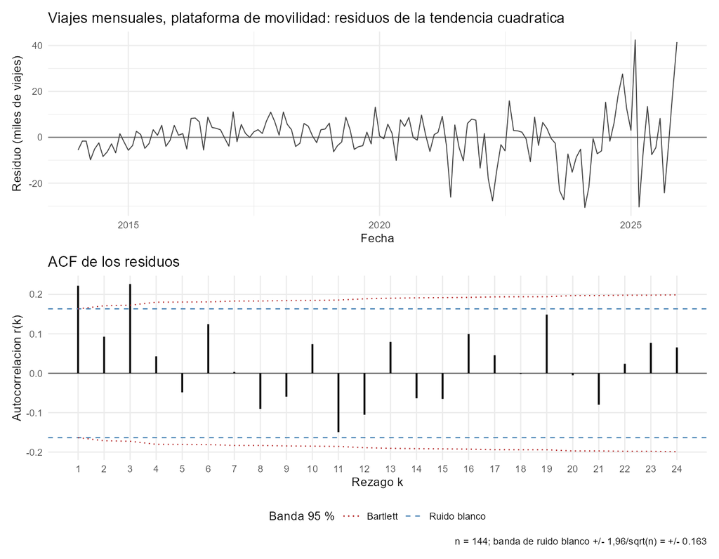

Residuos en el tiempo y su correlograma, tendencia cuadratica.

Rezagos de la ACF de los residuos fuera de la banda $\pm 1{,}96/\sqrt{n}$: 1, 3.

**Ljung–Box sobre los residuos.**

| Elemento | Contenido |
| --- | --- |
| 1. Hipotesis | H0: rho(1) = … = rho(24) = 0; H1: rho(k) != 0 para algun k en 1, …, 24 |
| 2. Estadistico y distribucion | Q = n(n+2) sum_{k=1}^{m} r_k^2/(n-k) ~ chi-cuadrado con 24 g.l. bajo H0 |
| 3. Region de rechazo (5 %) | Q > 36.415 |
| 4. Observado y valor p | observado = 38.1477; valor p = 0.03348 |
| 5. Decision | Se rechaza H0 al 5 % |
| 6. Lectura | Hay autocorrelacion conjunta significativa en los primeros 24 rezagos de los residuos de la tendencia cuadratica. |

**Jarque–Bera sobre los residuos.**

| Elemento | Contenido |
| --- | --- |
| 1. Hipotesis | H0: asimetria = 0 y curtosis = 3 (normalidad); H1: asimetria != 0 o curtosis != 3 |
| 2. Estadistico y distribucion | JB = n/6 [A^2 + (K - 3)^2/4] ~ chi-cuadrado con 2 g.l. (asintotica) bajo H0 |
| 3. Region de rechazo (5 %) | JB > 5.991 |
| 4. Observado y valor p | observado = 79.5292; valor p = < 2.2e-16 |
| 5. Decision | Se rechaza H0 al 5 % |
| 6. Lectura | Los errores no son normales: la banda +/-1,96 sd es solo heuristica. |

**Durbin–Watson (diagnóstico).** $d=1,447$, con $r_1=0,222$ y $2(1-r_1)=1,556$.

**Lectura de la tendencia cuadrática.** La curvatura es significativa ($t=19,4$), así que la serie no crece en línea recta. Los residuos conservan una autocorrelación débil ($r_1=0,22$, apenas fuera de la banda; Ljung–Box rechaza al 5 % con $p=0,033$, aunque no al 1 %) y no son normales: $JB=79,53$. La parábola trata la variabilidad como constante y los cambios grandes del final de la serie, cuando el nivel es alto, producen colas pesadas. La exponencial no tiene ese problema porque en logaritmos la variabilidad es estable.

**Código**

```r
bloque_6b("serie3", "tend_lineal")
```

#### 6.2.0.6 Tendencia lineal (contraste)

Ajuste por mínimos cuadrados sobre las 144 observaciones, 2 coeficientes; HAC con núcleo de Bartlett y $L=4$ rezagos.

| Coeficiente | Estimación | e.e. ordinario | e.e. HAC | HAC / ordinario | t robusta | Valor p |
| --- | --- | --- | --- | --- | --- | --- |
| beta0 (intercepto) | 35,9551 | 4,2320 | 9,1642 | 2,1655 | 3,9234 | 0.000135 |
| beta1 (t) | 2,4863 | 0,0506 | 0,1257 | 2,4819 | 19,7825 | < 1e-04 |

**Pruebas t con el error estándar robusto.**

| 1. Hipótesis | 2. Estadístico y distribución | 3. Región de rechazo | 4. Observado y valor p | 5. Decisión | 6. Lectura |
| --- | --- | --- | --- | --- | --- |
| H0: beta0 (intercepto) = 0; H1: beta0 (intercepto) != 0 | t = b / ee_HAC(b) ~ t de Student con 142 g.l. (aproximada) | \|t\| > 1.977 | t = 3.923; p = 0.000135 | Se rechaza H0 al 5 % | El nivel en t = 0 es distinto de cero. |
| H0: beta1 (t) = 0; H1: beta1 (t) != 0 | t = b / ee_HAC(b) ~ t de Student con 142 g.l. (aproximada) | \|t\| > 1.977 | t = 19.783; p = <1e-04 | Se rechaza H0 al 5 % | Hay tendencia significativa: un cambio de 2,486 miles de viajes por periodo. |

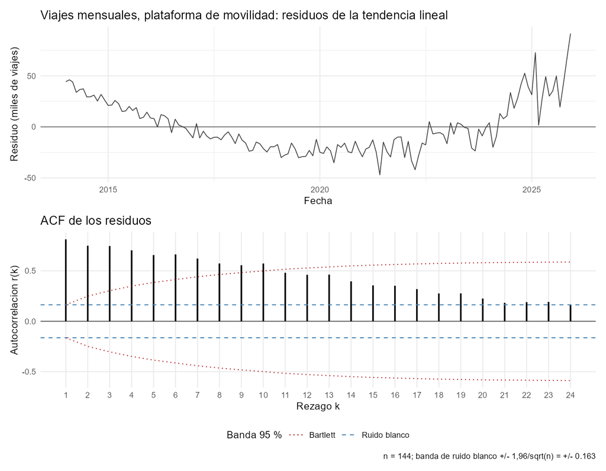

Residuos en el tiempo y su correlograma, tendencia lineal.

Rezagos de la ACF de los residuos fuera de la banda $\pm 1{,}96/\sqrt{n}$: 1-24.

**Ljung–Box sobre los residuos.**

| Elemento | Contenido |
| --- | --- |
| 1. Hipotesis | H0: rho(1) = … = rho(24) = 0; H1: rho(k) != 0 para algun k en 1, …, 24 |
| 2. Estadistico y distribucion | Q = n(n+2) sum_{k=1}^{m} r_k^2/(n-k) ~ chi-cuadrado con 24 g.l. bajo H0 |
| 3. Region de rechazo (5 %) | Q > 36.415 |
| 4. Observado y valor p | observado = 924.6398; valor p = < 2.2e-16 |
| 5. Decision | Se rechaza H0 al 5 % |
| 6. Lectura | Hay autocorrelacion conjunta significativa en los primeros 24 rezagos de los residuos de la tendencia lineal. |

**Jarque–Bera sobre los residuos.**

| Elemento | Contenido |
| --- | --- |
| 1. Hipotesis | H0: asimetria = 0 y curtosis = 3 (normalidad); H1: asimetria != 0 o curtosis != 3 |
| 2. Estadistico y distribucion | JB = n/6 [A^2 + (K - 3)^2/4] ~ chi-cuadrado con 2 g.l. (asintotica) bajo H0 |
| 3. Region de rechazo (5 %) | JB > 5.991 |
| 4. Observado y valor p | observado = 20.7254; valor p = 3.159e-05 |
| 5. Decision | Se rechaza H0 al 5 % |
| 6. Lectura | Los errores no son normales: la banda +/-1,96 sd es solo heuristica. |

**Durbin–Watson (diagnóstico).** $d=0,261$, con $r_1=0,812$ y $2(1-r_1)=0,375$.

**Lectura de la recta (contraste).** La pendiente es significativa, pero la recta no describe la serie: los residuos forman una U, primero positivos, luego negativos y otra vez positivos, y las 24 autocorrelaciones quedan fuera de la banda ($r_1=0,81$, $d=0,26$). Es la firma de una tendencia curva ajustada con una recta. El error HAC de la pendiente es 2,48 veces el ordinario: con residuos así, el error ordinario subestima mucho la incertidumbre.

## 6.3 Origen móvil

**Código**

```r
res$resumen6c |>
  dplyr::transmute(Serie = serie, `Transformación (sección 4)` = transformacion,
                   `Ganador h=1` = ganador, `Constantes` = parametros, Referente = referente,
                   `RMSE h=1 (ganador)` = RMSE1_ganador, `RMSE h=1 (referente)` = RMSE1_referente,
                   `Mejor h=H` = ganador_H, `RMSE h=H (mejor)` = RMSEH_ganador,
                   `RMSE h=H (referente)` = RMSEH_referente) |>
  knitr::kable(digits = 3, format.args = list(decimal.mark = ","))
```

Tabla 22: Ganador a h = 1, mejor método a h = H y referente de cada serie (RMSE de origen móvil).

| Serie | Transformación (sección 4) | Ganador h=1 | Constantes | Referente | RMSE h=1 (ganador) | RMSE h=1 (referente) | Mejor h=H | RMSE h=H (mejor) | RMSE h=H (referente) |
| --- | --- | --- | --- | --- | --- | --- | --- | --- | --- |
| serie1 | 1 | Holt-Winters aditivo | alpha = 0.9, beta = 0.1, gamma = 0.1 | Ingenuo | 16,884 | 16,999 | Media simple | 19,156 | 27,593 |
| serie2 | (1-B)(1-B^4) | Holt-Winters aditivo | alpha = 0.7, beta = 0.1, gamma = 0.1 | Ingenuo estacional | 38,208 | 92,180 | Tendencia con ficticias de suma cero | 41,300 | 90,351 |
| serie3 | log, (1-B) | Tendencia exponencial | sin constantes | Ingenuo | 18,309 | 23,033 | Tendencia exponencial | 18,993 | 37,375 |

**Serie 1: espera en estación**

**Código**

```r
bloque_6c("serie1")
```

Se evalúan 9 métodos con $n_0=144$ y $T=180$, todos sobre los mismos orígenes: 36 errores a $h=1$ (orígenes $o=n_0,\dots,T-1$) y 28 a $h=9$ (orígenes $o=n_0,\dots,T-9$). En cada origen el método recibe solo $y_1,\dots,y_o$. El referente es el **Ingenuo** (la razón de esa elección está en 6(a)); va como una fila más, calculada sobre los mismos orígenes, y ningún método que no lo supere se descarta de la tabla.

**Constantes elegidas en $y_1,\dots,y_{n_0}$** por MSE de un paso con `optimizar()`:

| Método | Constantes elegidas | MSE de un paso (estimación) |
| --- | --- | --- |
| Media movil | k = 7 | 375,125 |
| Suavizamiento exponencial simple | alpha = 0.04 | 330,704 |
| Doble media movil | k = 12 | 418,968 |
| Holt | alpha = 0.05, beta = 0.05 | 343,023 |
| Holt-Winters aditivo | alpha = 0.9, beta = 0.1, gamma = 0.1 | 356,844 |

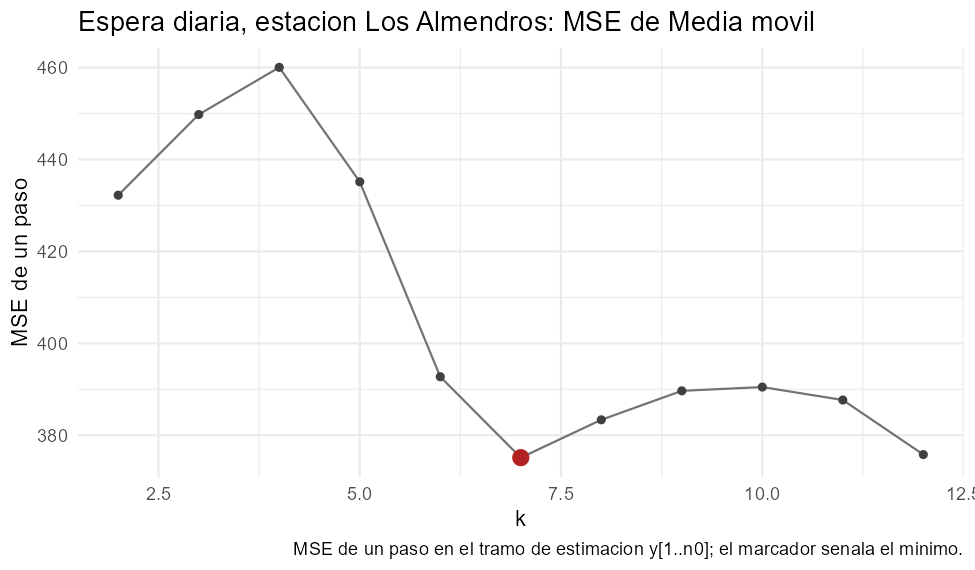

MSE de un paso en el tramo de estimación para Media movil.

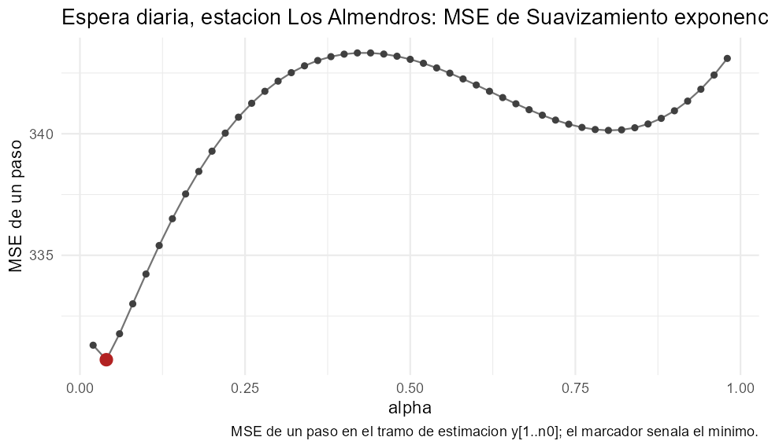

MSE de un paso en el tramo de estimación para Suavizamiento exponencial simple.

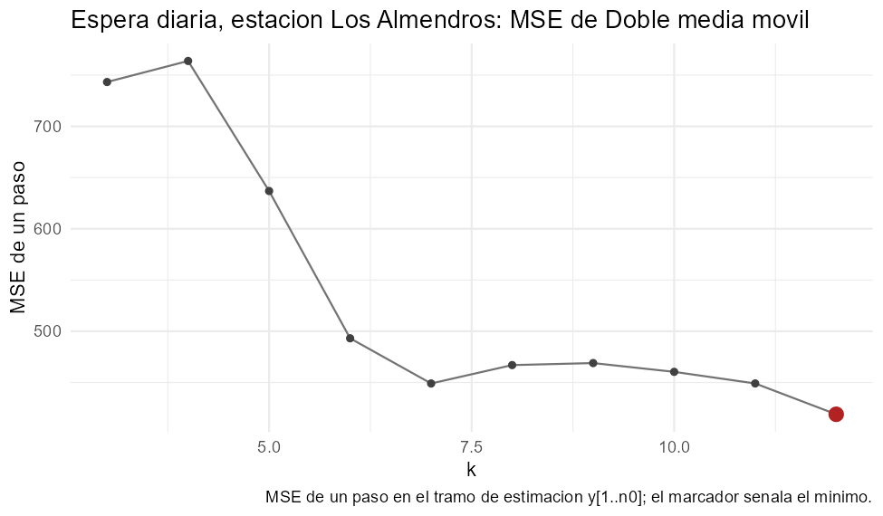

MSE de un paso en el tramo de estimación para Doble media movil.

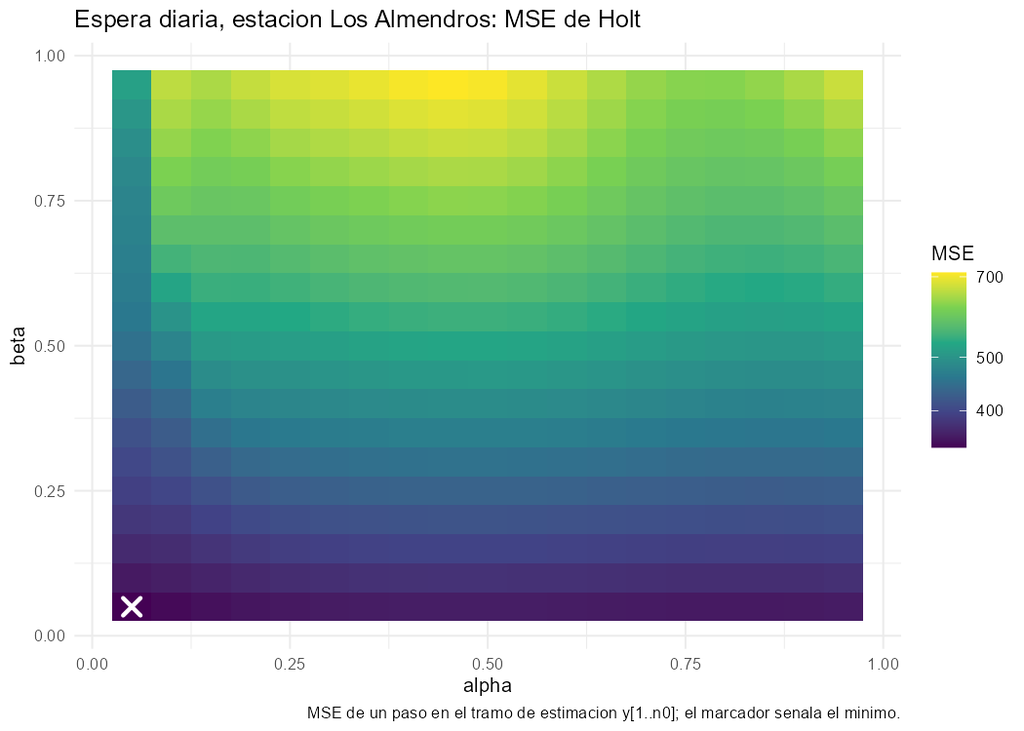

MSE de un paso en el tramo de estimación para Holt.

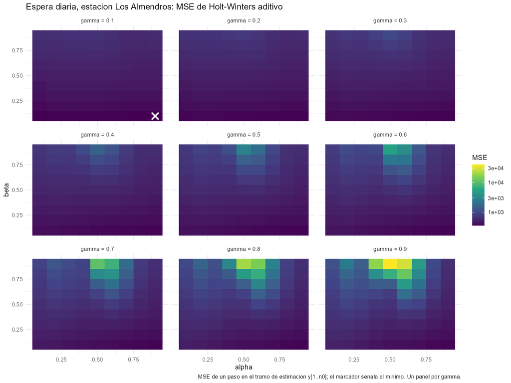

MSE de un paso en el tramo de estimación para Holt-Winters aditivo.

**Horizonte $h=1$** (ordenada de menor a mayor RMSE).

| Método | Rol | Constantes | n | RMSE | MAD | MAPE (%) | RMSE / RMSE del referente |
| --- | --- | --- | --- | --- | --- | --- | --- |
| Holt-Winters aditivo | contraste | alpha = 0.9, beta = 0.1, gamma = 0.1 | 36 | 16,884 | 13,086 | 4,398 | 0,993 |
| Ingenuo | referente | sin constantes | 36 | 16,999 | 13,194 | 4,425 | 1,000 |
| Media simple | sostenido | sin constantes | 36 | 18,051 | 15,480 | 5,240 | 1,062 |
| Suavizamiento exponencial simple | sostenido | alpha = 0.04 | 36 | 18,218 | 15,455 | 5,257 | 1,072 |
| Tendencia lineal | contraste | sin constantes | 36 | 18,522 | 15,802 | 5,399 | 1,090 |
| Holt | contraste | alpha = 0.05, beta = 0.05 | 36 | 18,806 | 15,776 | 5,387 | 1,106 |
| Media movil | sostenido | k = 7 | 36 | 19,028 | 14,921 | 5,017 | 1,119 |
| Doble media movil | contraste | k = 12 | 36 | 19,971 | 15,800 | 5,287 | 1,175 |
| Ingenuo estacional | contraste | sin constantes | 36 | 24,250 | 19,056 | 6,461 | 1,427 |

**Horizonte $h=9$** (ordenada de menor a mayor RMSE).

| Método | Rol | Constantes | n | RMSE | MAD | MAPE (%) | RMSE / RMSE del referente |
| --- | --- | --- | --- | --- | --- | --- | --- |
| Media simple | sostenido | sin constantes | 28 | 19,156 | 16,672 | 5,715 | 0,694 |
| Suavizamiento exponencial simple | sostenido | alpha = 0.04 | 28 | 20,174 | 17,735 | 6,124 | 0,731 |
| Tendencia lineal | contraste | sin constantes | 28 | 20,576 | 18,172 | 6,294 | 0,746 |
| Media movil | sostenido | k = 7 | 28 | 21,174 | 17,531 | 6,056 | 0,767 |
| Doble media movil | contraste | k = 12 | 28 | 21,803 | 17,783 | 6,083 | 0,790 |
| Holt | contraste | alpha = 0.05, beta = 0.05 | 28 | 21,828 | 18,975 | 6,595 | 0,791 |
| Ingenuo estacional | contraste | sin constantes | 28 | 25,847 | 21,071 | 7,273 | 0,937 |
| Ingenuo | referente | sin constantes | 28 | 27,593 | 22,857 | 7,857 | 1,000 |
| Holt-Winters aditivo | contraste | alpha = 0.9, beta = 0.1, gamma = 0.1 | 28 | 36,793 | 29,919 | 10,259 | 1,333 |

**Ganador a $h=1$.** El menor RMSE lo tiene **Holt-Winters aditivo** (alpha = 0.9, beta = 0.1, gamma = 0.1), con $16,88$ segundos frente a $17,00$ del referente (Ingenuo): una reducción de 0,7 %. **A $h=9$** el menor RMSE es de **Media simple** (sin constantes), con $19,16$ frente a $27,59$ del referente: una reducción de 30,6 %. A $h=1$ no superan al referente: Media simple, Suavizamiento exponencial simple, Tendencia lineal, Holt, Media movil, Doble media movil, Ingenuo estacional.

**Serie 2: pasajeros del aeropuerto**

**Código**

```r
bloque_6c("serie2")
```

Se evalúan 8 métodos con $n_0=96$ y $T=120$, todos sobre los mismos orígenes: 24 errores a $h=1$ (orígenes $o=n_0,\dots,T-1$) y 21 a $h=4$ (orígenes $o=n_0,\dots,T-4$). En cada origen el método recibe solo $y_1,\dots,y_o$. El referente es el **Ingenuo estacional** (la razón de esa elección está en 6(a)); va como una fila más, calculada sobre los mismos orígenes, y ningún método que no lo supere se descarta de la tabla.

**Constantes elegidas en $y_1,\dots,y_{n_0}$** por MSE de un paso con `optimizar()`:

| Método | Constantes elegidas | MSE de un paso (estimación) |
| --- | --- | --- |
| Holt | alpha = 0.1, beta = 0.2 | 17264,476 |
| Holt-Winters aditivo | alpha = 0.7, beta = 0.1, gamma = 0.1 | 2629,736 |
| Holt-Winters multiplicativo | alpha = 0.5, beta = 0.1, gamma = 0.4 | 3270,221 |

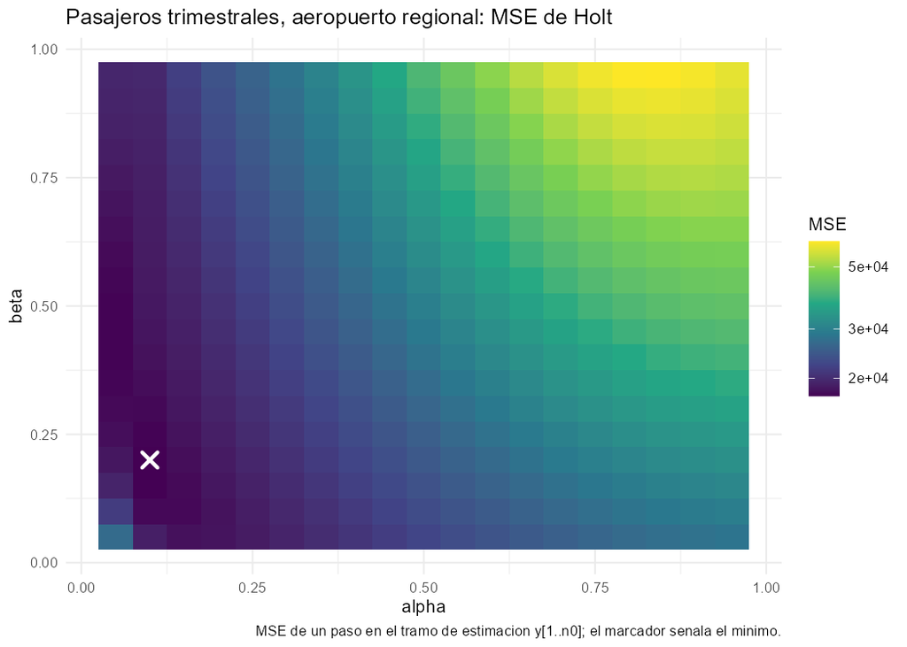

MSE de un paso en el tramo de estimación para Holt.

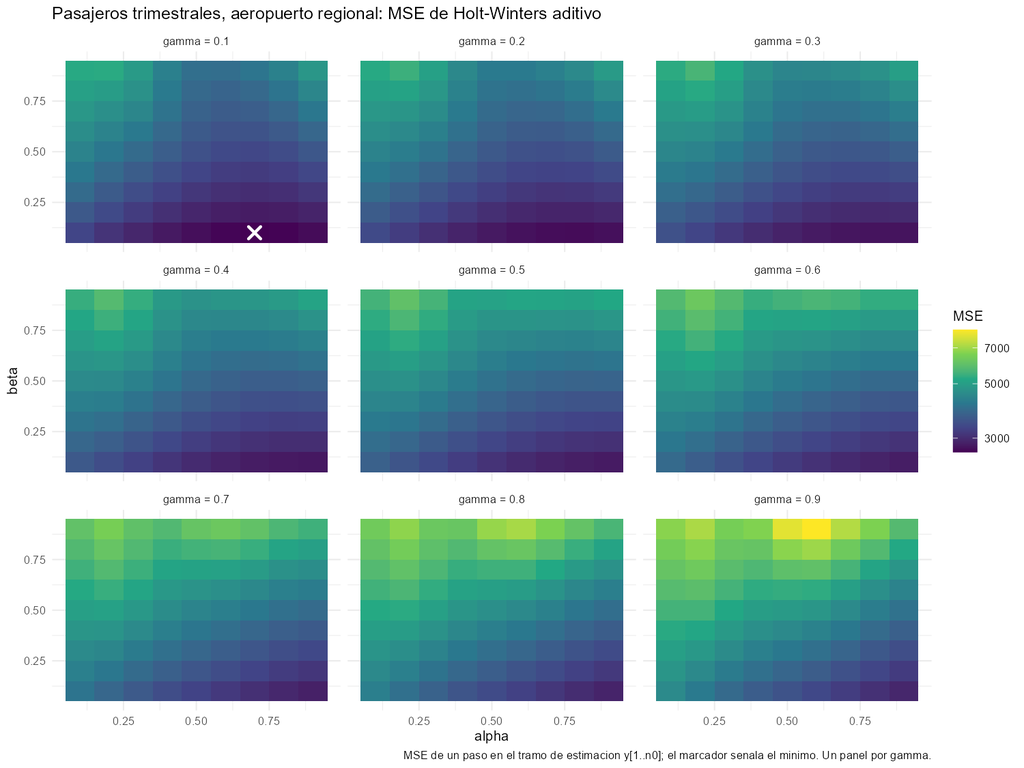

MSE de un paso en el tramo de estimación para Holt-Winters aditivo.

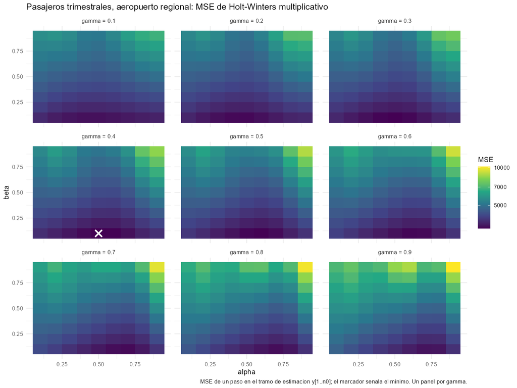

MSE de un paso en el tramo de estimación para Holt-Winters multiplicativo.

**Horizonte $h=1$** (ordenada de menor a mayor RMSE).

| Método | Rol | Constantes | n | RMSE | MAD | MAPE (%) | RMSE / RMSE del referente |
| --- | --- | --- | --- | --- | --- | --- | --- |
| Holt-Winters aditivo | sostenido | alpha = 0.7, beta = 0.1, gamma = 0.1 | 24 | 38,208 | 26,428 | 0,737 | 0,414 |
| Tendencia con ficticias de suma cero | sostenido | sin constantes | 24 | 38,764 | 30,941 | 0,848 | 0,421 |
| Holt-Winters multiplicativo | contraste | alpha = 0.5, beta = 0.1, gamma = 0.4 | 24 | 42,927 | 31,112 | 0,861 | 0,466 |
| Ingenuo estacional | referente | sin constantes | 24 | 92,180 | 83,729 | 2,297 | 1,000 |
| Tendencia lineal | contraste | sin constantes | 24 | 111,437 | 99,046 | 2,719 | 1,209 |
| Holt | contraste | alpha = 0.1, beta = 0.2 | 24 | 120,145 | 107,562 | 2,949 | 1,303 |
| Ingenuo | contraste | sin constantes | 24 | 150,563 | 133,896 | 3,664 | 1,633 |
| Media simple | contraste | sin constantes | 24 | 853,686 | 844,793 | 23,104 | 9,261 |

**Horizonte $h=4$** (ordenada de menor a mayor RMSE).

| Método | Rol | Constantes | n | RMSE | MAD | MAPE (%) | RMSE / RMSE del referente |
| --- | --- | --- | --- | --- | --- | --- | --- |
| Tendencia con ficticias de suma cero | sostenido | sin constantes | 21 | 41,300 | 33,842 | 0,920 | 0,457 |
| Holt-Winters multiplicativo | contraste | alpha = 0.5, beta = 0.1, gamma = 0.4 | 21 | 69,089 | 51,600 | 1,413 | 0,765 |
| Holt-Winters aditivo | sostenido | alpha = 0.7, beta = 0.1, gamma = 0.1 | 21 | 70,731 | 53,228 | 1,455 | 0,783 |
| Ingenuo | contraste | sin constantes | 21 | 90,351 | 83,376 | 2,281 | 1,000 |
| Ingenuo estacional | referente | sin constantes | 21 | 90,351 | 83,376 | 2,281 | 1,000 |
| Tendencia lineal | contraste | sin constantes | 21 | 104,700 | 92,075 | 2,501 | 1,159 |
| Holt | contraste | alpha = 0.1, beta = 0.2 | 21 | 110,334 | 92,210 | 2,500 | 1,221 |
| Media simple | contraste | sin constantes | 21 | 887,178 | 879,667 | 23,924 | 9,819 |

**Ganador a $h=1$.** El menor RMSE lo tiene **Holt-Winters aditivo** (alpha = 0.7, beta = 0.1, gamma = 0.1), con $38,21$ miles de pasajeros frente a $92,18$ del referente (Ingenuo estacional): una reducción de 58,6 %. **A $h=4$** el menor RMSE es de **Tendencia con ficticias de suma cero** (sin constantes), con $41,30$ frente a $90,35$ del referente: una reducción de 54,3 %. A $h=1$ no superan al referente: Tendencia lineal, Holt, Ingenuo, Media simple.

**Serie 3: viajes de la plataforma**

**Código**

```r
bloque_6c("serie3")
```

Se evalúan 9 métodos con $n_0=115$ y $T=144$, todos sobre los mismos orígenes: 29 errores a $h=1$ (orígenes $o=n_0,\dots,T-1$) y 24 a $h=6$ (orígenes $o=n_0,\dots,T-6$). En cada origen el método recibe solo $y_1,\dots,y_o$. El referente es el **Ingenuo** (la razón de esa elección está en 6(a)); va como una fila más, calculada sobre los mismos orígenes, y ningún método que no lo supere se descarta de la tabla.

**Constantes elegidas en $y_1,\dots,y_{n_0}$** por MSE de un paso con `optimizar()`:

| Método | Constantes elegidas | MSE de un paso (estimación) |
| --- | --- | --- |
| Suavizamiento exponencial simple | alpha = 0.66 | 72,418 |
| Doble media movil | k = 10 | 62,037 |
| Holt | alpha = 0.2, beta = 0.15 | 54,380 |
| Holt-Winters multiplicativo | alpha = 0.2, beta = 0.1, gamma = 0.1 | 51,478 |

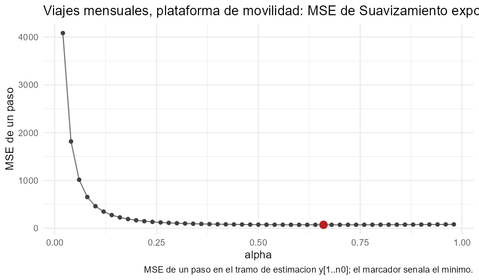

MSE de un paso en el tramo de estimación para Suavizamiento exponencial simple.

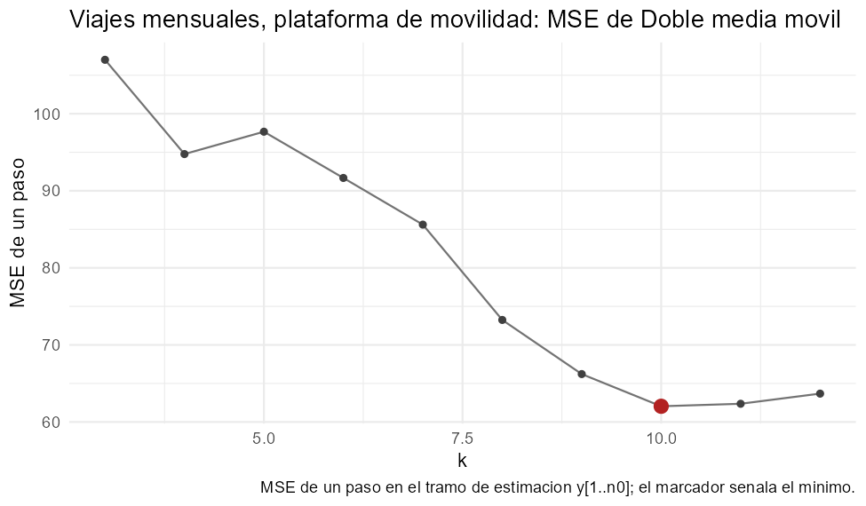

MSE de un paso en el tramo de estimación para Doble media movil.

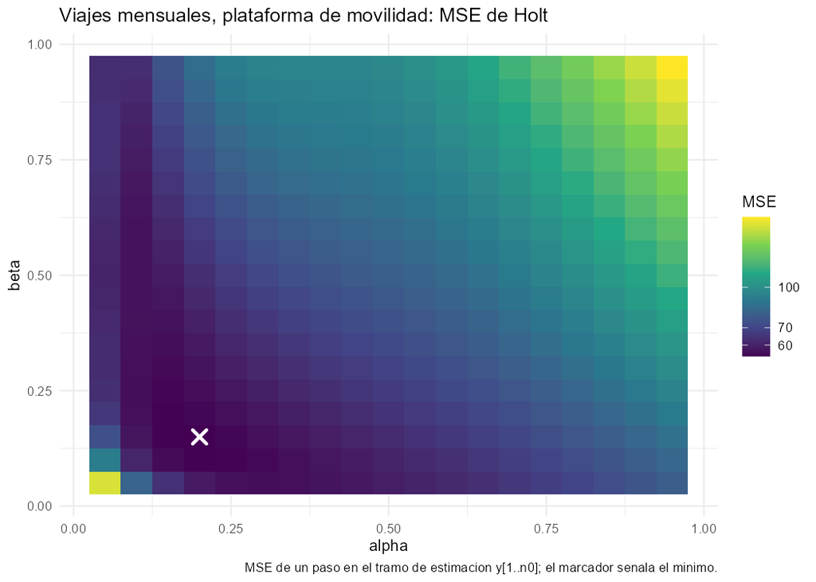

MSE de un paso en el tramo de estimación para Holt.

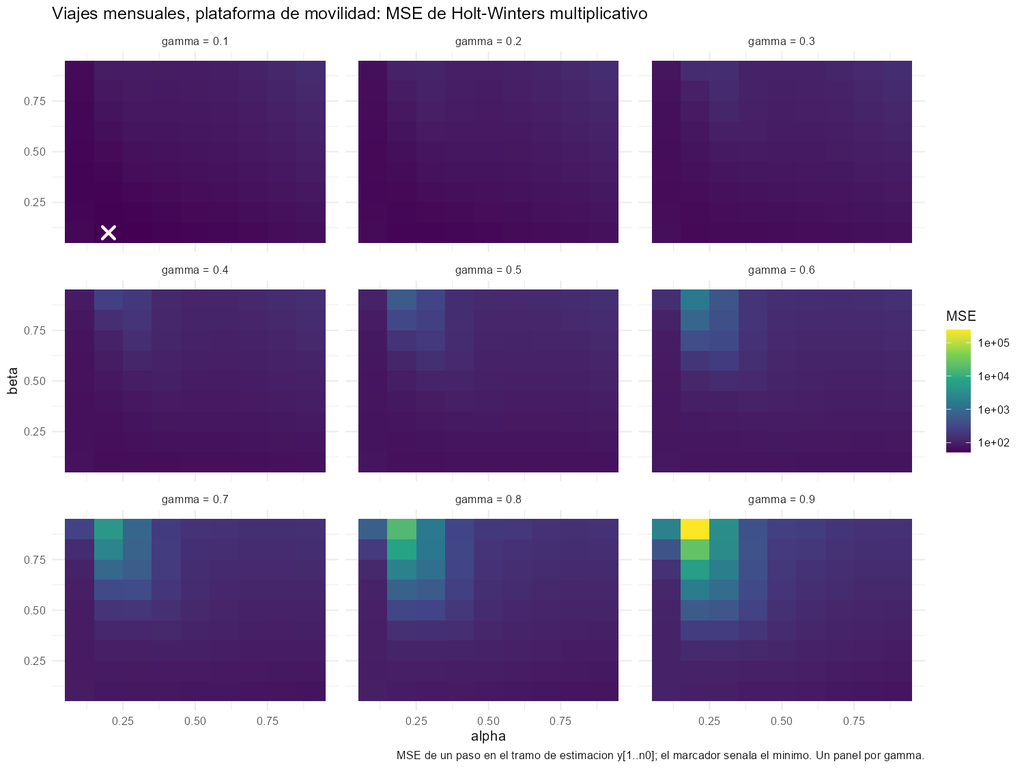

MSE de un paso en el tramo de estimación para Holt-Winters multiplicativo.

**Horizonte $h=1$** (ordenada de menor a mayor RMSE).

| Método | Rol | Constantes | n | RMSE | MAD | MAPE (%) | RMSE / RMSE del referente |
| --- | --- | --- | --- | --- | --- | --- | --- |
| Tendencia exponencial | sostenido | sin constantes | 29 | 18,309 | 14,480 | 3,799 | 0,795 |
| Holt-Winters multiplicativo | contraste | alpha = 0.2, beta = 0.1, gamma = 0.1 | 29 | 19,281 | 15,752 | 4,155 | 0,837 |
| Tendencia cuadratica | sostenido | sin constantes | 29 | 20,105 | 15,675 | 4,013 | 0,873 |
| Holt | sostenido | alpha = 0.2, beta = 0.15 | 29 | 20,373 | 16,316 | 4,246 | 0,884 |
| Suavizamiento exponencial simple | contraste | alpha = 0.66 | 29 | 21,476 | 17,439 | 4,468 | 0,932 |
| Doble media movil | sostenido | k = 10 | 29 | 22,280 | 17,665 | 4,582 | 0,967 |
| Ingenuo | referente | sin constantes | 29 | 23,033 | 18,610 | 4,787 | 1,000 |
| Tendencia lineal | contraste | sin constantes | 29 | 48,836 | 43,541 | 10,933 | 2,120 |
| Ingenuo estacional | contraste | sin constantes | 29 | 55,638 | 48,990 | 12,422 | 2,416 |

**Horizonte $h=6$** (ordenada de menor a mayor RMSE).

| Método | Rol | Constantes | n | RMSE | MAD | MAPE (%) | RMSE / RMSE del referente |
| --- | --- | --- | --- | --- | --- | --- | --- |
| Tendencia exponencial | sostenido | sin constantes | 24 | 18,993 | 14,942 | 3,758 | 0,508 |
| Tendencia cuadratica | sostenido | sin constantes | 24 | 23,120 | 17,992 | 4,441 | 0,619 |
| Holt-Winters multiplicativo | contraste | alpha = 0.2, beta = 0.1, gamma = 0.1 | 24 | 25,308 | 21,856 | 5,520 | 0,677 |
| Holt | sostenido | alpha = 0.2, beta = 0.15 | 24 | 27,911 | 24,564 | 6,152 | 0,747 |
| Doble media movil | sostenido | k = 10 | 24 | 32,244 | 27,994 | 7,015 | 0,863 |
| Ingenuo | referente | sin constantes | 24 | 37,375 | 31,671 | 7,929 | 1,000 |
| Suavizamiento exponencial simple | contraste | alpha = 0.66 | 24 | 38,435 | 32,700 | 8,170 | 1,028 |
| Tendencia lineal | contraste | sin constantes | 24 | 59,252 | 55,254 | 13,633 | 1,585 |
| Ingenuo estacional | contraste | sin constantes | 24 | 60,000 | 54,442 | 13,543 | 1,605 |

**Ganador a $h=1$.** El menor RMSE lo tiene **Tendencia exponencial** (sin constantes), con $18,31$ miles de viajes frente a $23,03$ del referente (Ingenuo): una reducción de 20,5 %. **A $h=6$** el menor RMSE es de **Tendencia exponencial** (sin constantes), con $18,99$ frente a $37,37$ del referente: una reducción de 49,2 %. A $h=1$ no superan al referente: Tendencia lineal, Ingenuo estacional.

## 6.4 Validación del ganador

Se validan los errores de origen móvil **a un paso** del ganador de cada serie, $e_{o+1}=y_{o+1}-\hat y_{o+1}$ para $o=n_0,\dots,T-1$, y no los residuos de un ajuste. Si el método aprovechó toda la estructura de la serie, esos errores deben tener media cero (prueba t), ser incorrelacionados (Ljung–Box referido a $\chi^2_m$, sin restar grados de libertad) y, para que la banda del pronóstico tenga sentido, ser aproximadamente normales (Jarque–Bera). El correlograma usa $m=\min\{\lfloor n/4\rfloor,24\}$ y su banda $\pm1{,}96/\sqrt{n}$ se calcula sobre el número $n$ de errores, no sobre $T$. Para Ljung–Box se usa el $m$ de la sección 5 limitado a $\lfloor n/4\rfloor$, porque con pocos errores no se pueden pedir más rezagos de los que sostienen. Durbin–Watson es solo diagnóstico, leído con $d\approx 2(1-r_1)$. Con tan pocos errores las pruebas tienen poca potencia: que no rechacen no demuestra que el método sea perfecto.

**Serie 1: espera en estación**

**Código**

```r
bloque_6d("serie1")
```

Ganador a $h=1$: **Holt-Winters aditivo**. $n=36$ errores; $m=9$ en el correlograma y $m=9$ en Ljung–Box; error medio $0,146$ y desviación estándar $17,122$.

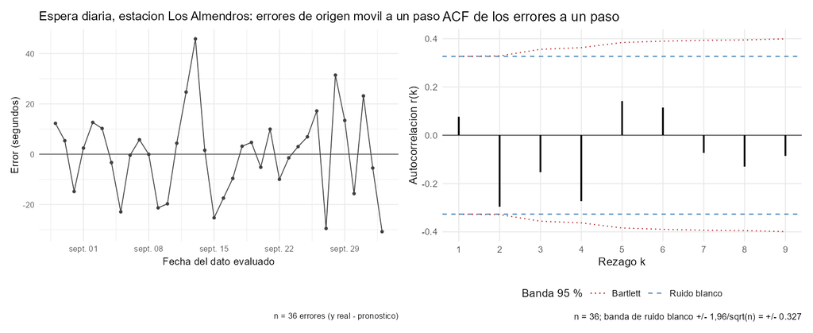

Errores de origen móvil a un paso en el tiempo (izquierda) y su correlograma con la banda calculada sobre el número de errores (derecha).

**Prueba t de media cero.**

| Elemento | Contenido |
| --- | --- |
| 1. Hipotesis | H0: mu_e = 0; H1: mu_e != 0 |
| 2. Estadistico y distribucion | t = ebar / (s_e / sqrt(n)) ~ t de Student con 35 g.l. bajo H0 |
| 3. Region de rechazo (5 %) | \|t\| > 2.030 |
| 4. Observado y valor p | observado = 0.0513; valor p = 0.9594 |
| 5. Decision | No se rechaza H0 al 5 % |
| 6. Lectura | No hay evidencia de sesgo en los pronosticos a un paso. |

**Prueba de Ljung–Box.**

| Elemento | Contenido |
| --- | --- |
| 1. Hipotesis | H0: rho(1) = … = rho(9) = 0; H1: rho(k) != 0 para algun k en 1, …, 9 |
| 2. Estadistico y distribucion | Q = n(n+2) sum_{k=1}^{m} r_k^2/(n-k) ~ chi-cuadrado con 9 g.l. bajo H0 |
| 3. Region de rechazo (5 %) | Q > 16.919 |
| 4. Observado y valor p | observado = 10.8416; valor p = 0.2867 |
| 5. Decision | No se rechaza H0 al 5 % |
| 6. Lectura | No hay evidencia de autocorrelacion conjunta en los primeros 9 rezagos de los errores a un paso; es compatible con ruido blanco. |

**Prueba de Jarque–Bera.**

| Elemento | Contenido |
| --- | --- |
| 1. Hipotesis | H0: asimetria = 0 y curtosis = 3 (normalidad); H1: asimetria != 0 o curtosis != 3 |
| 2. Estadistico y distribucion | JB = n/6 [A^2 + (K - 3)^2/4] ~ chi-cuadrado con 2 g.l. (asintotica) bajo H0 |
| 3. Region de rechazo (5 %) | JB > 5.991 |
| 4. Observado y valor p | observado = 0.5184; valor p = 0.7717 |
| 5. Decision | No se rechaza H0 al 5 % |
| 6. Lectura | No se rechaza normalidad de los errores. |

**Durbin–Watson (diagnóstico).** $d=1,739$, con $r_1=0,077$ y $2(1-r_1)=1,847$. Un $d$ cerca de 2 no sugiere autocorrelación de primer orden; no dice nada de los rezagos mayores.

**Sensibilidad de Ljung–Box a $m$.**

| m | Q | g.l. | Valor crítico | Valor p |
| --- | --- | --- | --- | --- |
| 4 | 7.909 | 4 | 9.488 | 0.095 |
| 9 | 10.842 | 9 | 16.919 | 0.287 |
| 18 | 16.485 | 18 | 28.869 | 0.559 |

**Estructura que queda.** Rezagos de la ACF fuera de la banda $\pm0,327$: ninguno. Ningun rezago de la ACF de los errores sale de la banda: no queda autocorrelacion que el metodo no aproveche.

**Serie 2: pasajeros del aeropuerto**

**Código**

```r
bloque_6d("serie2")
```

Ganador a $h=1$: **Holt-Winters aditivo**. $n=24$ errores; $m=6$ en el correlograma y $m=6$ en Ljung–Box; error medio $4,272$ y desviación estándar $38,785$.

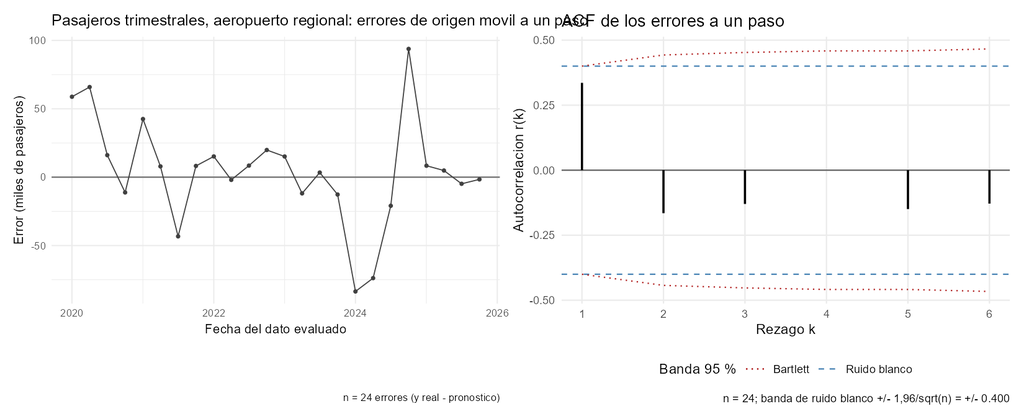

Errores de origen móvil a un paso en el tiempo (izquierda) y su correlograma con la banda calculada sobre el número de errores (derecha).

**Prueba t de media cero.**

| Elemento | Contenido |
| --- | --- |
| 1. Hipotesis | H0: mu_e = 0; H1: mu_e != 0 |
| 2. Estadistico y distribucion | t = ebar / (s_e / sqrt(n)) ~ t de Student con 23 g.l. bajo H0 |
| 3. Region de rechazo (5 %) | \|t\| > 2.069 |
| 4. Observado y valor p | observado = 0.5395; valor p = 0.5947 |
| 5. Decision | No se rechaza H0 al 5 % |
| 6. Lectura | No hay evidencia de sesgo en los pronosticos a un paso. |

**Prueba de Ljung–Box.**

| Elemento | Contenido |
| --- | --- |
| 1. Hipotesis | H0: rho(1) = … = rho(6) = 0; H1: rho(k) != 0 para algun k en 1, …, 6 |
| 2. Estadistico y distribucion | Q = n(n+2) sum_{k=1}^{m} r_k^2/(n-k) ~ chi-cuadrado con 6 g.l. bajo H0 |
| 3. Region de rechazo (5 %) | Q > 12.592 |
| 4. Observado y valor p | observado = 5.6409; valor p = 0.4646 |
| 5. Decision | No se rechaza H0 al 5 % |
| 6. Lectura | No hay evidencia de autocorrelacion conjunta en los primeros 6 rezagos de los errores a un paso; es compatible con ruido blanco. |

**Prueba de Jarque–Bera.**

| Elemento | Contenido |
| --- | --- |
| 1. Hipotesis | H0: asimetria = 0 y curtosis = 3 (normalidad); H1: asimetria != 0 o curtosis != 3 |
| 2. Estadistico y distribucion | JB = n/6 [A^2 + (K - 3)^2/4] ~ chi-cuadrado con 2 g.l. (asintotica) bajo H0 |
| 3. Region de rechazo (5 %) | JB > 5.991 |
| 4. Observado y valor p | observado = 0.7638; valor p = 0.6825 |
| 5. Decision | No se rechaza H0 al 5 % |
| 6. Lectura | No se rechaza normalidad de los errores. |

**Durbin–Watson (diagnóstico).** $d=1,226$, con $r_1=0,336$ y $2(1-r_1)=1,328$. Un $d$ por debajo de 2 indica autocorrelación positiva de primer orden en los errores.

**Sensibilidad de Ljung–Box a $m$.**

| m | Q | g.l. | Valor crítico | Valor p |
| --- | --- | --- | --- | --- |
| 3 | 4.334 | 3 | 7.815 | 0.228 |
| 6 | 5.641 | 6 | 12.592 | 0.465 |
| 12 | 7.949 | 12 | 21.026 | 0.789 |

**Estructura que queda.** Rezagos de la ACF fuera de la banda $\pm0,400$: ninguno. Ningun rezago de la ACF de los errores sale de la banda: no queda autocorrelacion que el metodo no aproveche.

**Serie 3: viajes de la plataforma**

**Código**

```r
bloque_6d("serie3")
```

Ganador a $h=1$: **Tendencia exponencial**. $n=29$ errores; $m=7$ en el correlograma y $m=7$ en Ljung–Box; error medio $-1,472$ y desviación estándar $18,572$.

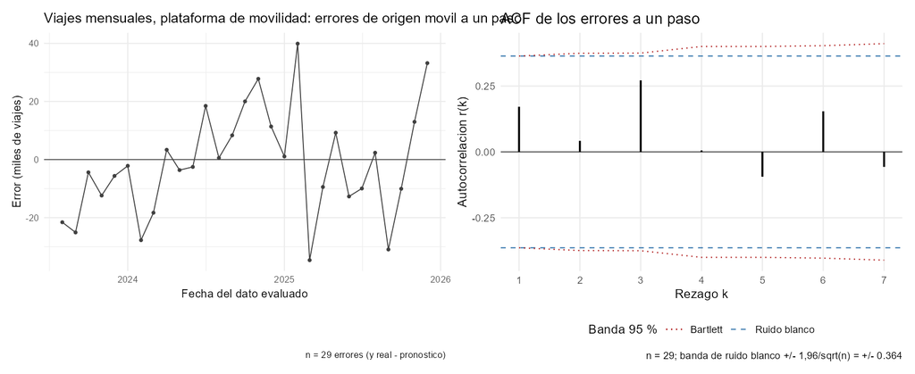

Errores de origen móvil a un paso en el tiempo (izquierda) y su correlograma con la banda calculada sobre el número de errores (derecha).

**Prueba t de media cero.**

| Elemento | Contenido |
| --- | --- |
| 1. Hipotesis | H0: mu_e = 0; H1: mu_e != 0 |
| 2. Estadistico y distribucion | t = ebar / (s_e / sqrt(n)) ~ t de Student con 28 g.l. bajo H0 |
| 3. Region de rechazo (5 %) | \|t\| > 2.048 |
| 4. Observado y valor p | observado = -0.4267; valor p = 0.6728 |
| 5. Decision | No se rechaza H0 al 5 % |
| 6. Lectura | No hay evidencia de sesgo en los pronosticos a un paso. |

**Prueba de Ljung–Box.**

| Elemento | Contenido |
| --- | --- |
| 1. Hipotesis | H0: rho(1) = … = rho(7) = 0; H1: rho(k) != 0 para algun k en 1, …, 7 |
| 2. Estadistico y distribucion | Q = n(n+2) sum_{k=1}^{m} r_k^2/(n-k) ~ chi-cuadrado con 7 g.l. bajo H0 |
| 3. Region de rechazo (5 %) | Q > 14.067 |
| 4. Observado y valor p | observado = 4.9485; valor p = 0.6663 |
| 5. Decision | No se rechaza H0 al 5 % |
| 6. Lectura | No hay evidencia de autocorrelacion conjunta en los primeros 7 rezagos de los errores a un paso; es compatible con ruido blanco. |

**Prueba de Jarque–Bera.**

| Elemento | Contenido |
| --- | --- |
| 1. Hipotesis | H0: asimetria = 0 y curtosis = 3 (normalidad); H1: asimetria != 0 o curtosis != 3 |
| 2. Estadistico y distribucion | JB = n/6 [A^2 + (K - 3)^2/4] ~ chi-cuadrado con 2 g.l. (asintotica) bajo H0 |
| 3. Region de rechazo (5 %) | JB > 5.991 |
| 4. Observado y valor p | observado = 0.5434; valor p = 0.7621 |
| 5. Decision | No se rechaza H0 al 5 % |
| 6. Lectura | No se rechaza normalidad de los errores. |

**Durbin–Watson (diagnóstico).** $d=1,481$, con $r_1=0,171$ y $2(1-r_1)=1,657$. Un $d$ por debajo de 2 indica autocorrelación positiva de primer orden en los errores.

**Sensibilidad de Ljung–Box a $m$.**

| m | Q | g.l. | Valor crítico | Valor p |
| --- | --- | --- | --- | --- |
| 3 | 3.553 | 3 | 7.815 | 0.314 |
| 7 | 4.948 | 7 | 14.067 | 0.666 |
| 14 | 19.403 | 14 | 23.685 | 0.150 |

**Estructura que queda.** Rezagos de la ACF fuera de la banda $\pm0,364$: ninguno. Ningun rezago de la ACF de los errores sale de la banda: no queda autocorrelacion que el metodo no aproveche.

## 6.5 Pronóstico final

Con el ganador de cada serie reajustado sobre las $T$ observaciones, y con las constantes elegidas en $y_1,\dots,y_{n_0}$, se pronostican los $H$ pasos siguientes. **La banda es heurística**: pronóstico $\pm\,1{,}96$ veces la desviación estándar de los errores de origen móvil a cada horizonte. No es un intervalo de confianza: supone errores centrados y aproximadamente normales, y con pocos orígenes por horizonte la desviación es una estimación ruidosa, sobre todo en los horizontes largos.

**Serie 1: espera en estación**

**Código**

```r
bloque_6e("serie1")
```

Método: **Holt-Winters aditivo** (alpha = 0.9, beta = 0.1, gamma = 0.1).

| h | Fecha | Pronóstico | Desv. de los errores del horizonte | n errores | Banda inferior (heurística) | Banda superior (heurística) |
| --- | --- | --- | --- | --- | --- | --- |
| 1 | 2025-10-04 | 290,81 | 17,12 | 36 | 257,25 | 324,37 |
| 2 | 2025-10-05 | 298,27 | 24,72 | 35 | 249,81 | 346,72 |
| 3 | 2025-10-06 | 299,35 | 28,11 | 34 | 244,26 | 354,44 |
| 4 | 2025-10-07 | 291,46 | 31,02 | 33 | 230,67 | 352,25 |
| 5 | 2025-10-08 | 288,94 | 30,25 | 32 | 229,65 | 348,23 |
| 6 | 2025-10-09 | 287,19 | 31,80 | 31 | 224,86 | 349,52 |
| 7 | 2025-10-10 | 285,40 | 34,26 | 30 | 218,25 | 352,54 |
| 8 | 2025-10-11 | 287,43 | 36,47 | 29 | 215,95 | 358,91 |
| 9 | 2025-10-12 | 294,89 | 37,44 | 28 | 221,52 | 368,27 |

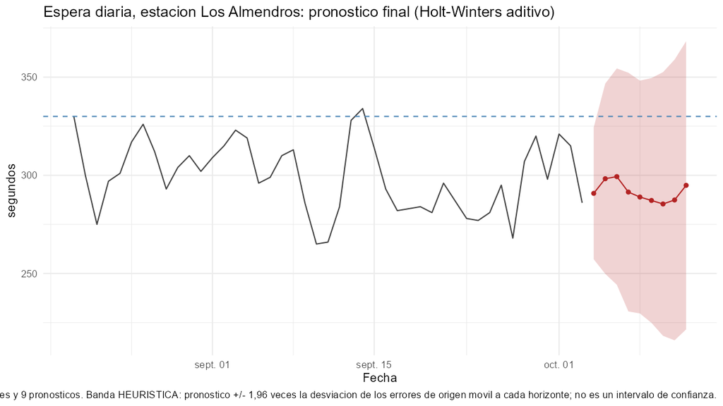

Último tramo de la serie, pronóstico final y banda heurística, que no es un intervalo de confianza.

**Código**

```r
z <- res$res6e$serie1
cat("**Insumo para la sección 8.** La decisión del viernes cubre de lunes a domingo, $h=3,\\dots,9$. ",
    "Con la misma heurística (errores normales con la desviación de cada horizonte), la probabilidad de ",
    "superar los ", z$meta, " s cada día es:\n\n", sep = "")
```

**Insumo para la sección 8.** La decisión del viernes cubre de lunes a domingo, $h=3,\dots,9$. Con la misma heurística (errores normales con la desviación de cada horizonte), la probabilidad de superar los 330 s cada día es:

**Código**

```r
tabla_md(z$sobre_meta |>
           dplyr::transmute(h = h, Fecha = format(fecha), `Pronóstico` = pronostico,
                            `Desv. del error` = sd_error, `P(superar la meta)` = prob_supera),
         digits = 3, format.args = list(decimal.mark = ","))
```

| h | Fecha | Pronóstico | Desv. del error | P(superar la meta) |
| --- | --- | --- | --- | --- |
| 3 | 2025-10-06 | 299,347 | 28,106 | 0,138 |
| 4 | 2025-10-07 | 291,460 | 31,016 | 0,107 |
| 5 | 2025-10-08 | 288,939 | 30,252 | 0,087 |
| 6 | 2025-10-09 | 287,190 | 31,804 | 0,089 |
| 7 | 2025-10-10 | 285,395 | 34,258 | 0,096 |
| 8 | 2025-10-11 | 287,433 | 36,470 | 0,122 |
| 9 | 2025-10-12 | 294,891 | 37,436 | 0,174 |

**Código**

```r
cat("La suma de esas probabilidades, **", fmt(z$dias_esperados, 2),
    " días**, es el número de días de la semana siguiente en que se espera superar la meta. ",
    "Es una cifra heurística y se usa en 8 para comparar la multa esperada con el costo del refuerzo.\n\n", sep = "")
```

La suma de esas probabilidades, **0,81 días**, es el número de días de la semana siguiente en que se espera superar la meta. Es una cifra heurística y se usa en 8 para comparar la multa esperada con el costo del refuerzo.

**Serie 2: pasajeros del aeropuerto**

**Código**

```r
bloque_6e("serie2")
```

Método: **Holt-Winters aditivo** (alpha = 0.7, beta = 0.1, gamma = 0.1).

| h | Fecha | Pronóstico | Desv. de los errores del horizonte | n errores | Banda inferior (heurística) | Banda superior (heurística) |
| --- | --- | --- | --- | --- | --- | --- |
| 1 | 2026-01-01 | 3696,17 | 38,78 | 24 | 3620,15 | 3772,19 |
| 2 | 2026-04-01 | 3872,18 | 56,34 | 23 | 3761,76 | 3982,60 |
| 3 | 2026-07-01 | 4000,34 | 64,64 | 22 | 3873,65 | 4127,03 |
| 4 | 2026-10-01 | 3784,72 | 72,37 | 21 | 3642,88 | 3926,55 |

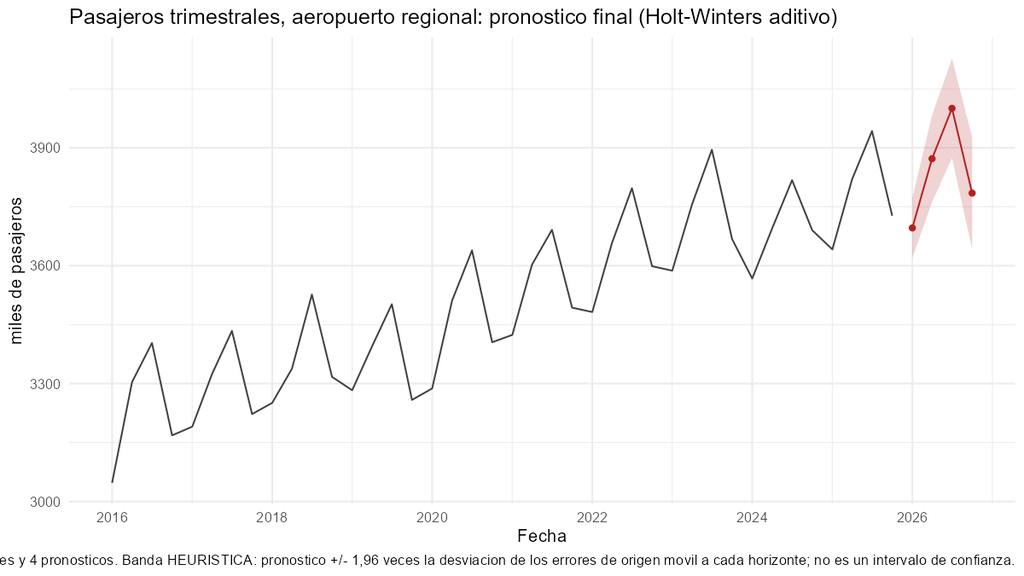

Último tramo de la serie, pronóstico final y banda heurística, que no es un intervalo de confianza.

**Serie 3: viajes de la plataforma**

**Código**

```r
bloque_6e("serie3")
```

Método: **Tendencia exponencial** (sin constantes).

| h | Fecha | Pronóstico | Desv. de los errores del horizonte | n errores | Banda inferior (heurística) | Banda superior (heurística) |
| --- | --- | --- | --- | --- | --- | --- |
| 1 | 2026-01-01 | 458,49 | 18,57 | 29 | 422,08 | 494,89 |
| 2 | 2026-02-01 | 464,05 | 18,62 | 28 | 427,55 | 500,55 |
| 3 | 2026-03-01 | 469,68 | 18,36 | 27 | 433,69 | 505,66 |
| 4 | 2026-04-01 | 475,38 | 18,89 | 26 | 438,35 | 512,41 |
| 5 | 2026-05-01 | 481,15 | 19,09 | 25 | 443,74 | 518,56 |
| 6 | 2026-06-01 | 486,98 | 19,38 | 24 | 448,99 | 524,97 |

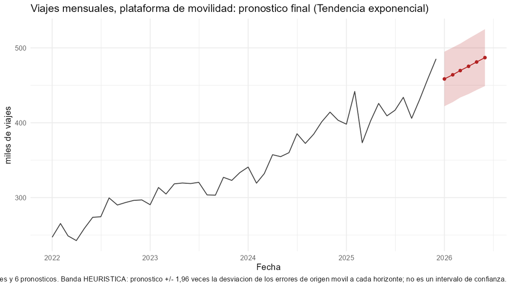

Último tramo de la serie, pronóstico final y banda heurística, que no es un intervalo de confianza.

# 7 Conclusión técnica

**Serie 1: espera en estación (tipo I, sin transformación).** La serie es de tipo I: nivel estable alrededor de 298,8 s, sin tendencia ni estacionalidad, con $r_1=0{,}48$. No necesita transformación, porque diferenciar sube la varianza de 323,6 a 334,7 s², como predice la identidad $\mathrm{Var}(\nabla Y_t)=2\gamma(0)-2\gamma(1)$ en una serie ya estacionaria. A $h=1$ gana Holt–Winters aditivo ($\alpha=0{,}9$, $\beta=0{,}1$, $\gamma=0{,}1$) con RMSE de 16,88 s frente a 17,00 s del ingenuo, una reducción de solo 0,7 %: en la práctica no se distingue del referente, y con $\alpha=0{,}9$ el método casi repite el último dato. El siguiente es la media simple, con 18,05 s. A $h=9$, el horizonte de la decisión del viernes, gana la media simple con 19,16 s frente a 27,59 s del ingenuo (30,6 % menos), mientras que Holt–Winters queda último con 36,79 s (1,33 veces el referente). Los $n=36$ errores a un paso del ganador no dejan estructura aprovechable: error medio de 0,15 s con desviación de 17,12 s, ningún rezago de la ACF fuera de la banda $\pm0{,}327$ (los mayores son $r_2=-0{,}30$ y $r_4=-0{,}27$), $d=1{,}74$ y Ljung–Box con $Q=10{,}84$ ($m=9$, $p=0{,}287$). Con tan pocos errores las pruebas tienen poca potencia, así que ese resultado no demuestra que el método sea perfecto.

**Serie 2: pasajeros del aeropuerto (tipo IV, $(1-B)(1-B^4)$).** La serie tiene tendencia lineal creciente y estacionalidad aditiva de período $s=4$. La transformación $(1-B)(1-B^4)$ la vuelve plausiblemente estacionaria: la varianza baja de 305.557 a 4.183, queda $r_1=-0{,}057$ (sin señal de sobrediferenciación) y la media es 0,56 miles de pasajeros, a 0,09 errores estándar del 0. A $h=1$ gana Holt–Winters aditivo ($\alpha=0{,}7$, $\beta=0{,}1$, $\gamma=0{,}1$) con RMSE de 38,21 miles de pasajeros frente a 92,18 del ingenuo estacional, una reducción de 58,6 %. A $h=4$, el horizonte del plan anual, gana la tendencia con ficticias de suma cero con 41,30 frente a 90,35 (54,3 % menos), por delante de Holt–Winters aditivo (70,73). Los $n=24$ errores a un paso del ganador tienen error medio de 4,27 y desviación de 38,79 miles de pasajeros, ningún rezago fuera de la banda $\pm0{,}400$ y $Q=5{,}64$ ($m=6$, $p=0{,}465$). Queda una señal débil sin aprovechar: $r_1=0{,}34$, cerca de la banda, y $d=1{,}23$, lo que sugiere autocorrelación positiva de corto plazo en los errores, que con $n=24$ la prueba no detecta.

**Serie 3: viajes de la plataforma (tipo III, $\log Y_t$ y $(1-B)$).** La serie tiene tendencia curva sin estacionalidad y una variabilidad que crece con el nivel. La transformación $\log Y_t$ seguida de $(1-B)$ la vuelve plausiblemente estacionaria: la varianza baja de 0,255 a 0,00269 y la de los cambios se mantiene estable entre mitades (0,00266 y 0,00274). Queda $r_1=-0{,}42$, una cautela de posible sobrediferenciación leve. Gana la tendencia exponencial, sin constantes que elegir, en los dos horizontes: a $h=1$ con RMSE de 18,31 miles de viajes frente a 23,03 del ingenuo (20,5 % menos) y a $h=6$ con 18,99 frente a 37,37 (49,2 % menos). Los $n=29$ errores a un paso tienen error medio de $-1{,}47$ y desviación de 18,57 miles de viajes, ningún rezago fuera de la banda $\pm0{,}364$ (el mayor es $r_3=0{,}27$), $d=1{,}48$ y $Q=4{,}95$ ($m=7$, $p=0{,}666$). Tampoco hay estructura detectable, con la misma limitación de potencia ($n=29$).

| Serie | Ganador a $h=1$ | RMSE ($h=1$) | RMSE referente | Mejor a $h=H$ | RMSE ($h=H$) | RMSE referente |
| --- | --- | --- | --- | --- | --- | --- |
| 1 (s) | Holt–Winters aditivo | 16,88 | 17,00 | Media simple | 19,16 | 27,59 |
| 2 (miles de pasajeros) | Holt–Winters aditivo | 38,21 | 92,18 | Tendencia con ficticias | 41,30 | 90,35 |
| 3 (miles de viajes) | Tendencia exponencial | 18,31 | 23,03 | Tendencia exponencial | 18,99 | 37,37 |

# 8 Argumentos para los interesados

Esta sección traduce los resultados de las secciones anteriores para quienes toman, ejecutan o sufren las decisiones que cada serie describe y que no conocen el curso. Las cifras son las del análisis. Dos advertencias valen para toda la sección: las bandas que se citan son heurísticas (el pronóstico más o menos 1,96 veces el error típico observado en la evaluación) y no intervalos de confianza, y las probabilidades de la serie 1 se calculan con la misma heurística.

## 8.1 Mapa de interesados

En cada tabla, “por defecto” quiere decir que el pronóstico queda por debajo de lo que ocurre y “por exceso” que queda por encima. Las celdas marcadas *(inferido)* no vienen del contexto: son una lectura del equipo. Donde el contexto no da una cifra en pesos, se dice y no se inventa.

### 8.1.1 Serie 1: espera en la estación Los Almendros

Tabla 23: Mapa de interesados de la serie 1.

| Interesado | Decisión concreta con el pronóstico | Error por defecto | Error por exceso |
| --- | --- | --- | --- |
| Operador de la estación | Cada viernes decide cuántos buses de refuerzo despacha la semana siguiente | No refuerza y el promedio del día pasa de 330 s: multa de 12 millones de pesos por día | Refuerza sin necesidad: 1,1 millones de pesos por bus y por día |
| Gerencia del sistema | Vigila el cumplimiento del contrato y aprueba el presupuesto de operación *(inferido)* | Multas por incumplimiento: 12 millones de pesos por día sobre la meta | Pago de refuerzos que no cambian el resultado: 1,1 millones por bus y por día |
| Usuarios | No deciden; ajustan la hora de salida según la espera que esperan encontrar *(inferido)* | Esperas de más de 5,5 minutos (330 s) sin aviso; costo en tiempo, sin cifra en pesos | Sin costo directo |

Un error por defecto cuesta unas 11 veces lo que cuesta un error por exceso (12 frente a 1,1 millones de pesos, por día y por bus).

### 8.1.2 Serie 2: pasajeros del aeropuerto

Tabla 24: Mapa de interesados de la serie 2.

| Interesado | Decisión concreta con el pronóstico | Error por defecto | Error por exceso |
| --- | --- | --- | --- |
| Concesionario | Presenta cada año el plan de personal de seguridad y de apertura de salas para los cuatro trimestres siguientes | Congestión en los filtros: sanciones y pérdida de rutas (el contexto no da la cifra en pesos) | 90 millones de pesos por cada sala abierta sin pasajeros, por trimestre |
| Aerolíneas | Planean frecuencias y rutas sobre la capacidad que el aeropuerto declara *(inferido)* | Demoras en los filtros y riesgo de perder rutas (sin cifra) | Sin costo directo en el contexto |
| Autoridad aeronáutica | Revisa el plan y sanciona la congestión *(inferido)* | Debe sancionar por filtros congestionados (sin cifra) | Aprueba un plan sobredimensionado; el costo lo asume el concesionario |
| Pasajeros | No deciden | Filas largas en seguridad | Sin costo directo |

### 8.1.3 Serie 3: viajes de la plataforma de movilidad

Tabla 25: Mapa de interesados de la serie 3.

| Interesado | Decisión concreta con el pronóstico | Error por defecto | Error por exceso |
| --- | --- | --- | --- |
| Gerencia de operaciones | Contrata capacidad de servidores por semestre y abre la vinculación de conductores, un proceso de tres meses | Cada viaje que no se atiende se pierde y deteriora la calificación (el contexto no da la cifra en pesos) | Servidores contratados y conductores vinculados sin viajes que atender (sin cifra) |
| Conductores | Deciden si se vinculan y cuánto trabajan según la demanda esperada *(inferido)* | Pocos conductores para la demanda: jornadas más largas *(inferido)* | Demasiados conductores: menos viajes y menos ingreso por conductor *(inferido)* |
| Secretaría de movilidad | Regula el número de vehículos autorizados | Autoriza pocos vehículos y quedan viajes sin atender | Autoriza vehículos de más: congestión y vehículos subutilizados *(inferido)* |
| Usuarios | No deciden | Viajes que no se atienden | Sin costo directo |

## 8.2 El argumento

**Serie 1: espera en estación**

**Afirmación.** La semana siguiente se espera superar los 330 segundos de espera en menos de un día de los siete, así que no conviene reforzar toda la semana; a lo sumo, un bus el domingo y el lunes, que son los días de mayor riesgo.

**Evidencia.**

- En las 180 mediciones diarias, la espera promedio estuvo en 298,8 s, con un mínimo de 255 s y un máximo de 353 s. La meta de 330 s queda 31 s por encima de ese promedio.
- Para la semana del lunes 6 al domingo 12 de octubre de 2025, el pronóstico va de 285,4 a 299,3 s. El error típico del pronóstico crece de 28 s (lunes) a 37 s (domingo).
- La probabilidad aproximada de superar los 330 s cada día, y lo que costaría esperar la multa frente a mandar un bus:

Tabla 26: Riesgo diario de superar la meta y costo del refuerzo, serie 1.

| Día | Pronóstico (s) | Probabilidad de superar 330 s | Multa esperada (millones de pesos) | Un bus (millones de pesos) |
| --- | --- | --- | --- | --- |
| Lunes 6 | 299,3 | 13,8 % | 1,66 | 1,10 |
| Martes 7 | 291,5 | 10,7 % | 1,28 | 1,10 |
| Miércoles 8 | 288,9 | 8,7 % | 1,04 | 1,10 |
| Jueves 9 | 287,2 | 8,9 % | 1,07 | 1,10 |
| Viernes 10 | 285,4 | 9,6 % | 1,15 | 1,10 |
| Sábado 11 | 287,4 | 12,2 % | 1,46 | 1,10 |
| Domingo 12 | 294,9 | 17,4 % | 2,09 | 1,10 |
| **Semana** |  | **0,81 días** | **9,76** | **7,70** |

**Justificación.** La espera ha oscilado alrededor de 299 s, sin una tendencia a subir ni un patrón por día de la semana, y la meta está a unos 31 s de ese nivel, apenas un poco más que el error típico del pronóstico. Por eso pasar la meta es posible, pero poco frecuente: en promedio, menos de un día de la semana. Mandar un bus cuesta 1,1 millones y una multa cuesta 12, de modo que mandarlo solo tiene sentido un día cuando la probabilidad de pasar la meta supera 1,1 sobre 12, es decir, 9,2 %, y eso suponiendo que un bus basta para evitar la multa. Domingo, lunes y, en menor medida, sábado superan ese umbral con holgura; miércoles y jueves quedan por debajo, y martes y viernes quedan en el límite. Si se mandara un bus los siete días se pagarían 7,7 millones para evitar una multa esperada de 9,8 millones: la ganancia es de unos 2 millones en el mejor caso y desaparece si el bus no evita la multa del todo.

**Alcance.** La recomendación vale para la semana del 6 al 12 de octubre de 2025 (de 3 a 9 días después del viernes de la decisión) y debe recalcularse cada viernes. Supone que el nivel de espera no cambia (sin obras, cierres u otros cambios en la operación) y que un solo bus evita la multa del día, que es la hipótesis más favorable al refuerzo; si un bus no basta, el refuerzo vale menos. Si se calcula el riesgo con el método que mejor funcionó a nueve días, el promedio histórico (error típico de 19,2 s), la probabilidad diaria baja a cerca de 5 % y ningún día justifica un bus; las dos lecturas coinciden en que no vale la pena reforzar toda la semana. La recomendación cambiaría si la espera de algún día supera los 350 s, que es aproximadamente el límite superior del lunes, o si cambian la multa o el costo del bus.

**Objeción.** *Si el error típico es de 28 a 37 segundos y la meta está solo 31 segundos por encima del promedio, ¿cómo sabemos que el domingo no será uno de los días malos?*

**Serie 2: pasajeros del aeropuerto**

**Afirmación.** En 2026 se esperan unos 15,4 millones de pasajeros, con el tercer trimestre como el más cargado, cerca de 4 millones, así que el personal de seguridad y las salas deben dimensionarse para ese trimestre y no para el promedio del año.

**Evidencia.**

- El pronóstico de cada trimestre de 2026, con su margen aproximado (el pronóstico más o menos 1,96 veces el error típico):

Tabla 27: Pronóstico de pasajeros por trimestre, serie 2.

| Trimestre de 2026 | Pronóstico (miles de pasajeros) | Margen aproximado (miles) | Rango aproximado (miles) |
| --- | --- | --- | --- |
| Primero | 3696,2 | ± 76,0 | 3620,2 a 3772,2 |
| Segundo | 3872,2 | ± 110,4 | 3761,8 a 3982,6 |
| Tercero | 4000,3 | ± 126,7 | 3873,7 a 4127,0 |
| Cuarto | 3784,7 | ± 141,8 | 3642,9 a 3926,6 |

- El total de los cuatro trimestres es de 15 353,4 miles de pasajeros. El tercer trimestre (4000,3) supera el máximo histórico de la serie, 3942,6 miles.
- El error típico va de 38,8 miles (primer trimestre) a 72,4 miles (cuarto), entre 1,0 % y 1,9 % del nivel pronosticado.
- Repetir el trimestre del año anterior se equivoca en promedio 92,2 miles a un trimestre; el método usado, 38,2 miles (58,6 % menos). A cuatro trimestres, el error baja de 90,4 a 70,7 miles (21,7 % menos).

**Justificación.** El tráfico del aeropuerto crece de manera sostenida y repite cada año la misma forma: sube hacia el tercer trimestre y baja al final del año. El método sigue las dos cosas a la vez, el crecimiento y la forma del año. La diferencia entre el trimestre más alto y el más bajo es de unos 304 mil pasajeros, entre cuatro y ocho veces el error típico (39 a 72 mil), así que la forma del año es una señal firme y no un efecto del azar. Abrir una sala de más cuesta 90 millones de pesos por trimestre; quedarse corto trae sanciones y pérdida de rutas, que el contexto no cuantifica. Si el concesionario considera que esas sanciones pesan más que 90 millones por sala, el margen superior del tercer trimestre (4127,0 miles) es una referencia prudente para el plan.

**Alcance.** El pronóstico cubre los cuatro trimestres de 2026 y es más confiable al principio (margen de 76 mil en el primer trimestre frente a 142 mil en el cuarto); no se evaluó para más de un año. Supone que no cambian las rutas ni las aerolíneas que operan y que el crecimiento sigue su ritmo. Cualquier cambio conocido de rutas que mueva más de 2 a 4 % del tráfico de un trimestre (76 mil es el 2,1 % del primero y 142 mil el 3,7 % del cuarto) debe sumarse o restarse a mano, porque el pronóstico no lo ve. En la comparación a cuatro trimestres de la sección 6.3, otro método, la tendencia con estacionalidad fija, tuvo un error típico menor (41,3 miles frente a 70,7); por eso el plan conviene contrastarlo con ese pronóstico antes de cerrarlo. Si un trimestre cae fuera del rango aproximado dos veces seguidas, hay que reestimar.

**Objeción.** *Repetir el trimestre del año anterior es más simple y es lo que ya se hace. ¿Por qué cambiar?*

**Respuesta.** Porque se equivoca más del doble a un trimestre: 92,2 miles de pasajeros frente a 38,2 del método usado. Repetir el trimestre pasado ignora que el tráfico crece, así que en una serie que sube cada año tiende a quedarse corto, que es justamente el error que trae sanciones y pérdida de rutas. A cuatro trimestres la ventaja se reduce a 21,7 % (70,7 frente a 90,4 miles); por eso el plan debe revisarse cada año con los datos nuevos.

**Serie 3: viajes de la plataforma**

**Afirmación.** Se esperan unos 2,84 millones de viajes entre enero y junio de 2026, con un aumento mes a mes hasta cerca de 487 mil viajes en junio, así que los servidores y los conductores deben contratarse para ese ritmo creciente y no para el nivel de hoy.

**Evidencia.**

- El pronóstico de cada mes de 2026, con su margen aproximado:

Tabla 28: Pronóstico de viajes por mes, serie 3.

| Mes de 2026 | Pronóstico (miles de viajes) | Rango aproximado (miles) |
| --- | --- | --- |
| Enero | 458,5 | 422,1 a 494,9 |
| Febrero | 464,1 | 427,6 a 500,6 |
| Marzo | 469,7 | 433,7 a 505,7 |
| Abril | 475,4 | 438,4 a 512,4 |
| Mayo | 481,2 | 443,7 a 518,6 |
| Junio | 487,0 | 449,0 a 525,0 |

- El semestre suma 2835,7 miles de viajes, y entre enero y junio el pronóstico sube 6,2 % (de 458,5 a 487,0 miles).
- El error típico es de 18,4 a 19,4 miles de viajes en cualquiera de los seis meses, alrededor del 4 % del nivel pronosticado.
- Repetir el último mes se equivoca en promedio 23,0 miles a un mes y 37,4 miles a seis; el método usado, 18,3 y 19,0 miles (20,5 % y 49,2 % menos).

**Justificación.** Los viajes han crecido con una curva, no con una línea recta: cada mes aumentan en un porcentaje parecido y la variación de un mes a otro crece con el nivel. El método que supone ese crecimiento constante en porcentaje fue el que mejor acertó al probarlo con datos que no había usado (29 meses para un mes de anticipación y 24 para seis meses). Repetir el último mes, en cambio, se equivoca el doble a seis meses porque ignora que la demanda sigue subiendo. Como vincular conductores toma tres meses, los de abril a junio deben empezar a vincularse desde enero, y para esos meses el pronóstico tiene el mismo error típico, cerca de 19 mil viajes. El contexto no da la cifra en pesos de un viaje perdido ni de un servidor ocioso; si perder viajes pesa más que sobrar capacidad, el margen superior (525,0 miles en junio) es la referencia prudente.

**Alcance.** El pronóstico cubre de enero a junio de 2026, seis meses, y no se evaluó para más. Supone que el crecimiento sigue su curva: sin cambios en el número de vehículos autorizados por la secretaría de movilidad, sin nuevos competidores y sin cambios de tarifa. Cambiaría si dos meses seguidos los viajes quedan por debajo del límite inferior del rango (422,1 miles en enero, 427,6 en febrero): sería la señal de que el crecimiento se frenó y hay que reestimar antes de contratar el semestre siguiente.

**Objeción.** *Si el crecimiento se frena, ¿no estaremos contratando capacidad de más durante todo el semestre?*

**Respuesta.** Es el riesgo real de este pronóstico: la capacidad se contrata por semestre y no se puede devolver a mitad de camino. Pero suponer que el crecimiento ya se detuvo ha sido el error más caro hasta ahora: en la evaluación a seis meses, repetir el último mes se equivocó 37,4 miles de viajes frente a 19,0 del método con crecimiento. Para limitar el riesgo, se contrata la capacidad del pronóstico central (487,0 miles en junio) y no la del margen superior, y se escalona la vinculación de conductores mes a mes: si junio termina por debajo de 449,0 miles, unos 8 % bajo el pronóstico, el crecimiento se frenó.

## 8.3 La nota para los interesados

La nota de una página, sin fórmulas ni términos del curso y con un solo gráfico por serie, está en `informe/nota-interesados.pdf`. Responde la pregunta de cada interesado (cuántos días se espera superar la meta en la serie 1, cuántos pasajeros por trimestre en la serie 2 y cuántos viajes por mes en la serie 3), traduce el error típico a una consecuencia para la decisión y dice lo que el pronóstico no puede garantizar.

# 9 README, reproducibilidad y uso de Git

**README.** El archivo `README.md`, en la raíz del repositorio, tiene en este orden: el enlace del repositorio y el código ST6Q98; las integrantes y lo que hizo cada una; la tabla de archivos con su contenido y su autor; los comandos exactos para correr el análisis y el tiempo de ejecución observado; la tabla de resultados por serie, con la transformación elegida, el ganador, sus parámetros y su RMSE frente al referente en $h=1$ y en $H$; y la declaración de uso de IA.

**Reproducibilidad.** Todo el análisis se corre desde la raíz del repositorio con un solo comando:

```
source("analisis/correr-todo.R")
```

El script usa rutas relativas y no pide intervención. Lee las tres series de `datos/` y verifica que coincidan con las fechas y longitudes declaradas en el enunciado. También comprueba las funciones propias contra las de R (`diff()`, `acf()`, `pacf()`, `Box.test()`, `lm()`). Las figuras quedan en `figs/` con el prefijo `serie1-`, `serie2-` o `serie3-`, y los resultados en `figs/resultados.rds`, que es el archivo que lee este informe. La entrega se cerró con R 4.5.2 en Windows 10. La salida completa de `sessionInfo()` está en `sesion-info.txt`. El informe se renderiza con:

```
quarto render informe/informe.qmd
```

**Uso de Git.** El trabajo se llevó en GitHub con commits de las tres integrantes: Mariana Castaño Celis (`mcastanoce-ux`), Sarah Catalina Criollo García (`Sarah-Cr1ollo`) y Sofia Cadavid Rueda (`Sofia-Cadavid-Rueda`). Cada commit corresponde a un avance concreto: secciones 2 a 5, puntos 6(a) y 6(b), cierre de las secciones 6 y 7, README, nota y exposición. El `.gitignore` excluye `.Rhistory`, `.RData` y `.Rproj.user`. El commit de entrega lleva la etiqueta `v1.0`.